# Multiple micronutrient supplementation pilot intervention for pregnant women in Botswana

BMIN503/EPID600 Final Project

Author

Jingni Pan

# 1 Overview

This project was a hybrid implementation-effectiveness pilot intervention of Multiple Micronutrient Supplementation (MMS) for pregnant women in Botswana. The primary goal was to assess the program’s reach (penetration) and its effects on maternal hemoglobin levels and adverse birth outcomes using a Difference-in-Difference (DiD) analysis of data from the Tsepamo Study.Dr. Caniglia shared this idea and access to the dataset with me, and help me set up a rigorous analysis plan. From her, I learned the rigorous process of defining the intervention periods and using the non-intervention clinics as a comparison group to ensure the validity of the causal estimate when studying the effects of MMS strategies. Dr. Ruggieri helped narrow down to my current topic focusing on Botswana.

# 2 Introduction

Micronutrient deficiencies during pregnancy are a major public health issue, particularly in low- and middle-income countries (LMICs), where they contribute significantly to maternal anemia, poor fetal growth, and increased risk of adverse birth outcomes.1,2 According to the World Health Organization (WHO), an estimated 32 million pregnant women globally are affected by anemia, most of whom live in LMICs.3 Iron and folic acid supplementation (IFA) has long been the standard of care, yet it often fails to address the multiple concurrent micronutrient deficiencies that women face during pregnancy.

Multiple micronutrient supplementation (MMS), particularly the United Nations International Multiple Micronutrient Antenatal Preparation (UNIMMAP), has been recommended as a more effective alternative to IFA. MMS provides 15 essential vitamins and minerals, including iron, folic acid, zinc, vitamin A, and iodine.4 A systematic review of randomized controlled trials found that compared to IFA, MMS reduced the risk of low birthweight by 12%, preterm birth by 8%, and small for gestational age (SGA) births by 9%.2 MMS has also been shown to improve maternal hemoglobin levels, reduce maternal mortality in some contexts, and promote better long-term health outcomes in children.5 Moreover, recent cost-effectiveness analyses suggest that MMS offers greater health and economic benefits than IFA, with studies reporting positive benefit–cost ratios ranging from 2:1 to 23:1 depending on country context.6,7

Despite these promising findings, MMS is not yet widely adopted in sub-Saharan Africa. In Botswana, maternal and child health continue to face significant challenges. The country has a maternal mortality ratio estimated at 155 deaths per 100,000 live births, and nearly 50% of pregnant women register for antenatal care (ANC) after the first trimester, missing the opportunity for early intervention.8,9 An HIV prevalence of 24% among pregnant women further compounds the risks of anemia and poor pregnancy outcomes.10 A recent large-scale cohort study in Botswana involving over 96,000 women found that MMS users had lower risks of preterm birth, very preterm birth, and low birth weight compared to those on IFA, with the strongest link seen among women with HIV.11 Further, this study found that fewer than 60% of pregnant women in Botswana received guideline-concordant supplementation. Qualitative interviews conducted with pregnant women identified important barriers to IFA, such as stockouts, insufficient education, side effects, poverty, pill burden, and poor adherence, which may similarly affect MMS uptake.12 Taken together, this evidence suggests that MMS may outperform both IFA and iron-only supplementation in Botswana’s clinic-based ANC system, while also underscoring the need to address structural barriers like supplement stockouts, education, and delayed ANC registration.

In light of the efficacy of MMS, well documented in clinical trials, the WHO has updated its guidelines to now recommend MMS “in the context of rigorous research.” WHO and UNICEF specifically call for countries considering MMS programs to generate rigorous implementation research to understand the acceptability, feasibility, equity, and sustainability of switching from IFA to MMS.13 Despite studies in Bangladesh, Indonesia, and Mali, no implementation study has yet been conducted in Botswana. 14–16 This highlights the importance of generating evidence specific to Botswana’s health system and maternal population.

To address these gaps, we conducted a hybrid implementation-effectiveness pilot intervention of providing MMS to ANCs in Botswana. Specifically, we assessed the reach, feasibility, acceptability, and appropriateness of providing MMS to pregnant women through routine ANC services at clinics across three urban, rural, and semi-urban regions in Botswana and measured its effect on maternal hemoglobin levels and adverse birth outcomes through linkage with a nationwide birth outcomes surveillance study (The Tsepamo Study). In doing this, we hope to prove the necessity of transitioning the policy recommendation from IFA to MMS.

# 3 Methods

##Linkage to Tsepamo Study (Data Cleaning)

To assess the primary implementation outcome and all effectiveness outcomes of interest, we leveraged individual-level clinical data collected in the Tsepamo study, which has been conducting birth outcomes surveillance in Botswana since 2014. The Tsepamo study captures delivery data from government hospitals throughout Botswana, including hospitals in Gaborone, Molepolole, and Palapye, and covers up to 72% of births nationwide. Data are abstracted from maternity obstetric records at the time of delivery, including ANC clinic and visits, diagnoses, medications (including MMS), HIV status, and birth outcomes. We used the ANC clinic and date of the first ANC clinic visit (the booking date) recorded in Tsepamo to link our MMS intervention data with the Tsepamo database. To minimize the potential for oversampling shorter pregnancies and to ensure all individuals included in the analysis had the potential to be pregnant for 40 weeks, we restricted our analysis to individuals with an estimated start of pregnancy at least 40 weeks before the day we abstracted the data from Tsepamo (Sep 3, 2025).

```r
# Load all neceaary packages
library(haven)
library(dplyr)
library(lubridate)
library(tidyverse)
```

```r
#Read a SAS dataset (.sas7bdat)
tsepamo <- read_sas("~/Desktop/tsepamo_updated_5sep25.sas7bdat")
# View the data
print(tsepamo)
```

```
# A tibble: 205,106 × 157
   record_id  site cliniccode bookdate   matage maritalstat national  educ occup
       <dbl> <dbl>      <dbl> <date>      <dbl>       <dbl>    <dbl> <dbl> <dbl>
 1 100305939     1       5422 2019-01-30     29           1        1     3     2
 2 100305941     1      88888 2018-10-08     26           1        1     2     3
 3 100305942     1      15330 2018-11-13     20           1        1     2     3
 4 100305943     1      15330 2018-12-13     26           2        1     2     2
 5 100305944     1      29301 2018-10-29     34           2        1     3     3
 6 100305945     1       3320 2018-12-07     39           2        1     3     3
 7 100305946     1      15401 2019-03-11     18          99        1     2     2
 8 100305947     1      15403 2019-02-08     29           1        1     2     3
 9 100305948     1      15302 2019-05-15     19           1        1     3     1
10 100305949     1      15329 2018-12-22     23           1        1     2     2
# ℹ 205,096 more rows
# ℹ 148 more variables: grav <dbl>, para <dbl>, hx_preterm <dbl>,
#   hx_stillbirth <dbl>, anymedhist___1 <dbl>, anymedhist___2 <dbl>,
#   anymedhist___3 <dbl>, anymedhist___4 <dbl>, anymedhist___5 <dbl>,
#   anymedhist___6 <dbl>, anymedhist___7 <dbl>, anymedhist___8 <dbl>,
#   anymedhist___9 <dbl>, anymedhist___10 <dbl>, anymedhist___11 <dbl>,
#   anymedhist___12 <dbl>, anymedhist___13 <dbl>, anymedhist___0 <dbl>, …
```

```r
# Only keep data from the 13 intervention clinics
mms <- tsepamo %>%         #=intervclinics
  filter(
    cliniccode %in% c(5302, 5303, 5323, 15312, 3319, 15325, 5306,
                      15331, 15341, 15329, 3201, 5318, 15335)
  )

# Separately, only keep data from the non-intervention clinics (all other clinics in gabs, moleps, palapye
# Creating non-intervention clinics dataset
nonintervclinics <- tsepamo %>%
  mutate(flagtokeep = if_else((cliniccode >= 5000 & cliniccode < 6000) |
                                (cliniccode >= 3000 & cliniccode < 4000) |
                                (cliniccode >= 15000 & cliniccode < 16000), 1, 0))
# Filter the non-intervention clinics based on the flag
nonintervclinics <- nonintervclinics %>%
  filter(flagtokeep == 1) %>%
  filter(!(cliniccode %in% c(5302, 5303, 5323, 15312, 3319, 15325, 5306,
                             15331, 15341, 15329, 3201, 5318, 15335)))

# Creating the MMS start date and end date based on clinic code T1
mms_timeline <- mms %>%                                 # Has 158+2 variables here
  mutate(
    mmsstartdate = case_when(
      cliniccode == 5302 ~ ymd("2024-08-23"),
      cliniccode == 5303 ~ ymd("2024-08-23"),
      cliniccode == 5323 ~ ymd("2024-08-23"),
      cliniccode == 15312 ~ ymd("2024-08-13"),
      cliniccode == 3319 ~ ymd("2024-09-06"),
      cliniccode == 15325 ~ ymd("2024-08-16"),
      cliniccode == 5306 ~ ymd("2024-08-23"),
      cliniccode == 15331 ~ ymd("2024-08-21"),
      cliniccode == 15341 ~ ymd("2024-08-16"),
      cliniccode == 15329 ~ ymd("2024-08-19"),
      cliniccode == 3201 ~ ymd("2024-09-06"),
      cliniccode == 5318 ~ ymd("2024-08-23"),
      cliniccode == 15335 ~ ymd("2024-08-16")
    ),
    mmsenddate = case_when(
      cliniccode == 5302 ~ ymd("2025-02-13"),
      cliniccode == 5303 ~ ymd("2025-03-17"),
      cliniccode == 5323 ~ ymd("2025-02-13"),
      cliniccode == 15312 ~ ymd("2025-02-20"),
      cliniccode == 3319 ~ ymd("2025-04-15"),
      cliniccode == 15325 ~ ymd("2025-02-20"),
      cliniccode == 5306 ~ ymd("2025-02-13"),
      cliniccode == 15331 ~ ymd("2025-02-20"),
      cliniccode == 15341 ~ ymd("2025-02-20"),
      cliniccode == 15329 ~ ymd("2025-02-20"),
      cliniccode == 3201 ~ ymd("2025-04-15"),
      cliniccode == 5318 ~ ymd("2025-02-13"),
      cliniccode == 15335 ~ ymd("2025-02-20")
    )
  ) %>%
  # Restriction step, 40 weeks before cut-off date Sep 03, 2025
  filter(lmp <= ymd("2024-11-27"))

# Filter mms data for women whose booking date is on or after the start of the pilot
Interv_T1 <- mms_timeline %>%    #Rename from mms_T1 to Interv_T1, for intervention clincis during intervention period
  filter(bookdate >= mmsstartdate)

# Creating T0 for intervention clinics
Interv_timeline_T0 <- mms_timeline %>%             #List past three timelines
  mutate(
    t0_start_1 = mmsstartdate - years(1),
    t0_end_1   = mmsenddate - years(1),
    t0_start_2 = mmsstartdate - years(2),
    t0_end_2   = mmsenddate - years(2),
    t0_start_3 = mmsstartdate - years(3),
    t0_end_3   = mmsenddate - years(3)
  ) %>%
  distinct(cliniccode, .keep_all = TRUE) %>%
  select(cliniccode, starts_with("t0_"))

Interv_T0 <- mms %>%        #For intervention clincis during non-intervention period
  left_join(Interv_timeline_T0, by = "cliniccode") %>%
  filter(
    (bookdate >= t0_start_1 & bookdate <= t0_end_1) |
      (bookdate >= t0_start_2 & bookdate <= t0_end_2) |
      (bookdate >= t0_start_3 & bookdate <= t0_end_3)
  )

# Create start and end dates for non-intervention clinics
nonintervclinics_timeline <- nonintervclinics %>%                          # Has 159+2 variables
  mutate(
    mmsstartdate = case_when(
      cliniccode >= 5000 & cliniccode < 6000 ~ ymd("2024-08-23"),
      cliniccode >= 15000 & cliniccode < 16000 ~ ymd("2024-08-16"),
      cliniccode >= 3000 & cliniccode < 4000 ~ ymd("2024-09-06")
    ),
    mmsenddate = case_when(
      cliniccode >= 5000 & cliniccode < 6000 ~ ymd("2025-02-13"),
      cliniccode >= 15000 & cliniccode < 16000 ~ ymd("2025-02-20"),
      cliniccode >= 3000 & cliniccode < 4000 ~ ymd("2025-04-15")
    )
  ) %>%

  # Restriction step, 40 weeks before cut-off date Sep 03, 2025
  filter(lmp <= ymd("2024-11-27"))

# Filter non-intervention clinics for women whose booking date is on or after the start of the pilot
noninterv_T1 <- nonintervclinics_timeline %>%
  filter(bookdate >= mmsstartdate)

# Creating T0 for nonintervention clinics
Noninterv_timeline_T0_ <- nonintervclinics_timeline %>%             #List past three timelines
  mutate(
    t0_start_1 = mmsstartdate - years(1),
    t0_end_1   = mmsenddate - years(1),
    t0_start_2 = mmsstartdate - years(2),
    t0_end_2   = mmsenddate - years(2),
    t0_start_3 = mmsstartdate - years(3),
    t0_end_3   = mmsenddate - years(3)
  ) %>%
  distinct(cliniccode, .keep_all = TRUE) %>%
  select(cliniccode, starts_with("t0_"))

noninterv_T0 <- nonintervclinics %>%   #use original nonintervention clinics dataset without T1 timeline
  left_join(Noninterv_timeline_T0_, by = "cliniccode") %>%
  filter(
    (bookdate >= t0_start_1 & bookdate <= t0_end_1) |
      (bookdate >= t0_start_2 & bookdate <= t0_end_2) |
      (bookdate >= t0_start_3 & bookdate <= t0_end_3)
  )# Create start and end dates for non-intervention clinics
nonintervclinics_timeline <- nonintervclinics %>%                          # Has 159+2 variables
  mutate(
    mmsstartdate = case_when(
      cliniccode >= 5000 & cliniccode < 6000 ~ ymd("2024-08-23"),
      cliniccode >= 15000 & cliniccode < 16000 ~ ymd("2024-08-16"),
      cliniccode >= 3000 & cliniccode < 4000 ~ ymd("2024-09-06")
    ),
    mmsenddate = case_when(
      cliniccode >= 5000 & cliniccode < 6000 ~ ymd("2025-02-13"),
      cliniccode >= 15000 & cliniccode < 16000 ~ ymd("2025-02-20"),
      cliniccode >= 3000 & cliniccode < 4000 ~ ymd("2025-04-15")
    )
  ) %>%
  # Restriction step, 40 weeks before cut-off date Sep 03, 2025
  filter(lmp <= ymd("2024-11-27"))

# Filter non-intervention clinics for women whose booking date is on or after the start of the pilot
noninterv_T1 <- nonintervclinics_timeline %>%
  filter(bookdate >= mmsstartdate)

# Creating T0 for nonintervention clinics
Noninterv_timeline_T0_ <- nonintervclinics_timeline %>%             #List past three timelines
  mutate(
    t0_start_1 = mmsstartdate - years(1),
    t0_end_1   = mmsenddate - years(1),
    t0_start_2 = mmsstartdate - years(2),
    t0_end_2   = mmsenddate - years(2),
    t0_start_3 = mmsstartdate - years(3),
    t0_end_3   = mmsenddate - years(3)
  ) %>%
  distinct(cliniccode, .keep_all = TRUE) %>%
  select(cliniccode, starts_with("t0_"))

noninterv_T0 <- nonintervclinics %>%   #use original nonintervention clinics dataset without T1 timeline
  left_join(Noninterv_timeline_T0_, by = "cliniccode") %>%
  filter(
    (bookdate >= t0_start_1 & bookdate <= t0_end_1) |
      (bookdate >= t0_start_2 & bookdate <= t0_end_2) |
      (bookdate >= t0_start_3 & bookdate <= t0_end_3)
  )
```

## 3.1 Implementation Outcomes

The implementation outcome was MMS penetration (often called “reach”),18 which is defined as the proportion of eligible individuals who participate in the intervention. We estimated penetration by calculating the proportion of deliveries for which there was documentation in the obstetric card that MMS was the first supplement prescribed during pregnancy. We used a difference-in-difference (DiD) approach to compare this proportion across time and clinic. We fit a linear probability model with indicators for the intervention group, the post-intervention period, and an interaction between the intervention group and post-intervention period. The coefficient for the interaction term quantifies the change in the proportion who received MMS from the pre-intervention to the post-intervention period, comparing the intervention clinics with the non-intervention clinics (a difference-in-difference). Each clinic had a unique intervention period, defined as the time between the first MMS distribution and 30 days after the sixth month of distribution. The pre-intervention period refers to the same calendar period in the three consecutive prior years. We included all clinics in Gaborone, Molepolole, and Palapye as non-intervention clinics in the primary analysis. Individuals were included in the analysis if they initiated ANC at one of the 13 intervention clinics or at a non-intervention clinic during either the intervention period or the corresponding pre-intervention period and delivered at a site included in Tsepamo. For non-intervention clinics, the intervention and pre-intervention periods were defined using the median intervention dates from clinics within the same geographic region.

```r
#Coding variable for MMNS, IFAS only, Iron only, No iron
tsepamo <- tsepamo %>%
  mutate(
    mmns = case_when(
      multivit == 1 ~ 3,                                      # MMNS
      (iron == 1 & folate == 1) | (fefol == 1) ~ 2,            # Iron + folatic acid but no other micronutrients
      (iron == 1 & folate == 0 & fefol == 0 & multivit == 0) ~ 1, # Iron only
      (iron == 0 & fefol == 0 & multivit == 0) ~ 0             # Not on iron
    )
  )

# Number MMS filled in Tsepamo among Women Presenting to ANC
# During T1
##Intervention
Interv_MMS_T1 <- Interv_T1 %>%
  group_by(cliniccode) %>%
  summarise(
    multivit_count = sum(multivit == 1, na.rm = TRUE))
Interv_MMS_T1
```

```
# A tibble: 13 × 2
   cliniccode multivit_count
        <dbl>          <int>
 1       3201             55
 2       3319             63
 3       5302             98
 4       5303             43
 5       5306             53
 6       5318             61
 7       5323             54
 8      15312            155
 9      15325             79
10      15329            147
11      15331             96
12      15335             82
13      15341             82
```

```r
##nonintervention
noninterv_MMS_T1 <- noninterv_T1 %>%
  group_by(cliniccode) %>%
  summarise(
    multivit_count = sum(multivit == 1, na.rm = TRUE))
noninterv_MMS_T1
```

```
# A tibble: 83 × 2
   cliniccode multivit_count
        <dbl>          <int>
 1       3302              0
 2       3303             27
 3       3304             20
 4       3310              6
 5       3313             39
 6       3315             15
 7       3316              0
 8       3320             67
 9       3322              4
10       3401              1
# ℹ 73 more rows
```

```r
# During T0
##Intervention
Interv_MMS_T0 <- Interv_T0 %>%
  group_by(cliniccode) %>%
  summarise(
    multivit_count = sum(multivit == 1, na.rm = TRUE))
Interv_MMS_T0
```

```
# A tibble: 13 × 2
   cliniccode multivit_count
        <dbl>          <int>
 1       3201            289
 2       3319             67
 3       5302            186
 4       5303            108
 5       5306             91
 6       5318            143
 7       5323            127
 8      15312             59
 9      15325             53
10      15329            286
11      15331            311
12      15335            168
13      15341            204
```

```r
##nonintervention
noninterv_MMS_T0 <- noninterv_T0 %>%
  group_by(cliniccode) %>%
  summarise(
    multivit_count = sum(multivit == 1, na.rm = TRUE))
noninterv_MMS_T0
```

```
# A tibble: 107 × 2
   cliniccode multivit_count
        <dbl>          <int>
 1       3044              1
 2       3220              2
 3       3303            137
 4       3304             59
 5       3310             67
 6       3313            113
 7       3315             55
 8       3316             29
 9       3320            147
10       3321              1
# ℹ 97 more rows
```

## 3.2 Effectiveness Outcomes

The primary effectiveness outcome was the mean change in hemoglobin during pregnancy, calculated as the difference between the second and first hemoglobin measurements recorded in the Tsepamo database. Specifically, the first hemoglobin must be measured before 24 weeks of gestation, and the second hemoglobin must be measured on or after 24 weeks of gestation. Secondary outcomes included the second hemoglobin value measured in pregnancy and a composite indicator of adverse birth outcomes, including stillbirth, preterm delivery (<37 weeks of gestation), in-hospital neonatal death (<28 days), and small-for-gestational-age (SGA). Preterm delivery, SGA, and low birth weight (<2500 grams) were also examined individually. As above, analyses of the effectiveness outcomes were restricted to individuals who delivered at a site included in Tsepamo.

### 3.2.1 Adverse Birth Outcome

```r
# Number any adverse birth outcome in Tsepamo among Women Presenting to ANC

## SGA and VSGA calculation functions

calculate_sga <- function(nga, bwt, gender, bwtgm) {
  # Vectorized version using case_when
  dplyr::case_when(
    is.na(nga) | is.na(bwt) | is.na(gender) | is.na(bwtgm) ~ NA_real_,
    bwt < bwtgm ~ 1L,  # Meets SGA criteria
    TRUE ~ 0L          # Does not meet criteria
  )
}

calculate_vsga <- function(nga, bwt, gender, bwtgm) {
  # Identical structure since logic is the same, just different thresholds
  dplyr::case_when(
    is.na(nga) | is.na(bwt) | is.na(gender) | is.na(bwtgm) ~ NA_real_,
    bwt < bwtgm ~ 1L,  # Meets VSGA criteria
    TRUE ~ 0L          # Does not meet criteria
  )
}

# Correct SGA and VSGA weight thresholds
sgawham <- setNames(c(530,600,690,780,880,1000,1130,1270,1430,1550,1820,2050,2270,2470,2640,2800,2940,3060,3170),
                    24:42)
sgawhaf <- setNames(c(500,570,650,740,830,940,1070,1200,1350,1530,1790,2020,2230,2410,2570,2710,2830,2930,3010),
                    24:42)

vsgawham <- setNames(c(470,540,610,690,790,890,1000,1130,1270,1300,1560,1800,2020,2220,2390,2550,2690,2820,2920),
                     24:42)
vsgawhaf <- setNames(c(440,510,580,660,740,840,950,1070,1200,1320,1570,1800,2000,2180,2340,2480,2600,2690,2770),
                     24:42)

calculate_growth_status <- function(bwt, bwtgm) {
  dplyr::case_when(
    is.na(bwt) | is.na(bwtgm) ~ NA_real_,  # Handle missing data
    bwt < bwtgm ~ 1L,                     # Meets criteria
    TRUE ~ 0L                              # Does not meet criteria
  )
}


## For Intervention period

# Intervention clinics
Interv_BD_T1 <- Interv_T1 %>%
  # First create prerequisite variables
  mutate(

    # Set implausible values to NA
    nga_clean = if_else(nga %in% 24:42, nga, NA_real_),

    # Flag outliers for review
    nga_flag = case_when(
      nga < 24 ~ "Below viability threshold",
      nga > 42 ~ "Post-term error",
      is.na(nga) ~ "Missing GA",
      TRUE ~ NA_character_
    ),

    # Stillbirth calculation
    stillbirth = case_when(
      infantstat %in% c(2, 3) ~ 1L,
      infantstat == 1 ~ 0L,
      TRUE ~ NA_integer_
    ),

    # Preterm calculations
    preterm = case_when(
      nga_clean %in% 24:36 ~ 1L,  # WHO preterm definition
      nga_clean >= 37 ~ 0L,
      TRUE ~ NA_integer_
    ),
    verypreterm = case_when(
      nga_clean %in% 24:31 ~ 1L,  # WHO very preterm
      nga_clean >= 32 ~ 0L,
      TRUE ~ NA_integer_
    ),

    # Low birth weight calculations
    lowbirthweight = case_when(
      bwt < 2500 ~ 1L,
      bwt >= 2500 ~ 0L,
      TRUE ~ NA_integer_
    ),

    # Neonatal death recoding
    nndeath_old = case_when(
      nndeath == 1 ~ 1L,
      nndeath == 0 ~ 0L,
      TRUE ~ NA_integer_
    ),
    nndeath_new = case_when(
      nndeath_old == 1 & alivebaby == 1 ~ NA_integer_,
      nndeath_old == 0 & alivebaby == 0 ~ NA_integer_,
      TRUE ~ nndeath_old
    ),

    # SGA/VSGA thresholds
    nga_char = as.character(round(nga_clean)),  # Handle decimal weeks if needed
    bwtgm_sga = case_when(
      gender == 0 ~ sgawham[nga_char],
      gender == 1 ~ sgawhaf[nga_char],
      TRUE ~ NA_real_
    ),
    bwtgm_vsga = case_when(
      gender == 0 ~ vsgawham[nga_char],
      gender == 1 ~ vsgawhaf[nga_char],
      TRUE ~ NA_real_
    ),

    # SGA/VSGA statuses (assuming these are sgawho_all/vsgawho_all)
    sgawho_all = case_when(
      bwt <= bwtgm_sga ~ 1L,
      bwt >= bwtgm_sga ~ 0L,
      TRUE ~ NA_integer_
    ),
    vsgawho_all = case_when(
      bwt <= bwtgm_vsga ~ 1L,
      bwt >= bwtgm_vsga ~ 0L,
      TRUE ~ NA_integer_
    )
  ) %>%

  # Now create composite outcomes
  mutate(
    composite = case_when(
      sgawho_all == 1 | preterm == 1 | stillbirth == 1 | nndeath_new == 1 ~ 1L,
      if_any(c(sgawho_all, preterm, stillbirth, nndeath_new), is.na) ~ NA_integer_,
      TRUE ~ 0L
    ),
    severe_composite = case_when(
      vsgawho_all == 1 | verypreterm == 1 | stillbirth == 1 | nndeath_new == 1 ~ 1L,
      if_any(c(vsgawho_all, verypreterm, stillbirth, nndeath_new), is.na) ~ NA_integer_,
      TRUE ~ 0L
    )
  ) %>%
  select(-nga_char)

Interv_BD_clinics_T1 <- Interv_BD_T1 %>%
  group_by(cliniccode) %>%
  summarise(
    n_total = sum(!is.na(composite)),                #n_total is the number of non-missing composite observations per clinic
    n_events = sum(composite == 1, na.rm = TRUE),    #n_events is the number of cases where composite == 1
    percent = mean(composite, na.rm = TRUE) * 100
  )
Interv_BD_clinics_T1
```

```
# A tibble: 13 × 4
   cliniccode n_total n_events percent
        <dbl>   <int>    <int>   <dbl>
 1       3201      72       21    29.2
 2       3319      78       26    33.3
 3       5302     108       38    35.2
 4       5303      43       12    27.9
 5       5306      58       24    41.4
 6       5318      66       21    31.8
 7       5323      68       16    23.5
 8      15312     173       41    23.7
 9      15325      92       27    29.3
10      15329     152       50    32.9
11      15331     151       45    29.8
12      15335      97       30    30.9
13      15341      86       27    31.4
```

```r
# Non-intervention clincis
noninterv_BD_T1 <- noninterv_T1 %>%
  # First create prerequisite variables
  mutate(
    # Stillbirth calculation
    stillbirth = case_when(
      infantstat %in% c(2, 3) ~ 1L,
      infantstat == 1 ~ 0L,
      TRUE ~ NA_integer_
    ),

    # Preterm calculations
    preterm = case_when(
      nga >= 24 & nga < 37 ~ 1L,
      nga >= 37 ~ 0L,
      TRUE ~ NA_integer_
    ),
    verypreterm = case_when(
      nga >= 24 & nga < 32 ~ 1L,
      nga >= 32 ~ 0L,
      TRUE ~ NA_integer_
    ),

    # Low birthweight calculations
    lowbirthweight = case_when(
      bwt < 2500 ~ 1L,
      bwt >= 2500 ~ 0L,
      TRUE ~ NA_integer_
    ),

    # Neonatal death recoding
    nndeath_old = case_when(
      nndeath == 1 ~ 1L,
      nndeath == 0 ~ 0L,
      TRUE ~ NA_integer_
    ),
    nndeath_new = case_when(
      nndeath_old == 1 & alivebaby == 1 ~ NA_integer_,
      nndeath_old == 0 & alivebaby == 0 ~ NA_integer_,
      TRUE ~ nndeath_old
    ),

    # SGA/VSGA thresholds
    nga_char = as.character(nga),
    bwtgm_sga = case_when(
      gender == 0 & nga %in% 24:42 ~ sgawham[nga_char],
      gender == 1 & nga %in% 24:42 ~ sgawhaf[nga_char],
      TRUE ~ NA_real_
    ),
    bwtgm_vsga = case_when(
      gender == 0 & nga %in% 24:42 ~ vsgawham[nga_char],
      gender == 1 & nga %in% 24:42 ~ vsgawhaf[nga_char],
      TRUE ~ NA_real_
    ),

    # SGA/VSGA statuses (assuming these are sgawho_all/vsgawho_all)
    sgawho_all = case_when(
      bwt < bwtgm_sga ~ 1L,
      bwt >= bwtgm_sga ~ 0L,
      TRUE ~ NA_integer_
    ),
    vsgawho_all = case_when(
      bwt < bwtgm_vsga ~ 1L,
      bwt >= bwtgm_vsga ~ 0L,
      TRUE ~ NA_integer_
    )
  ) %>%

  # Now create composite outcomes
  mutate(
    composite = case_when(
      sgawho_all == 1 | preterm == 1 | stillbirth == 1 | nndeath_new == 1 ~ 1L,
      if_any(c(sgawho_all, preterm, stillbirth, nndeath_new), is.na) ~ NA_integer_,
      TRUE ~ 0L
    ),
    severe_composite = case_when(
      vsgawho_all == 1 | verypreterm == 1 | stillbirth == 1 | nndeath_new == 1 ~ 1L,
      if_any(c(vsgawho_all, verypreterm, stillbirth, nndeath_new), is.na) ~ NA_integer_,
      TRUE ~ 0L
    )
  ) %>%
  select(-nga_char)

noninterv_BD_clinics_T1 <- noninterv_BD_T1 %>%
  group_by(cliniccode) %>%
  summarise(
    n_total = sum(!is.na(composite)),                #n_total is the number of non-missing composite observations per clinic
    n_events = sum(composite == 1, na.rm = TRUE),    #n_events is the number of cases where composite == 1
    percent = mean(composite, na.rm = TRUE) * 100
  )
noninterv_BD_clinics_T1
```

```
# A tibble: 83 × 4
   cliniccode n_total n_events percent
        <dbl>   <int>    <int>   <dbl>
 1       3302       1        0     0
 2       3303      39       13    33.3
 3       3304      22        8    36.4
 4       3310       7        1    14.3
 5       3313      58       19    32.8
 6       3315      26        7    26.9
 7       3316      16        5    31.2
 8       3320      94       32    34.0
 9       3322      26        8    30.8
10       3401       5        1    20
# ℹ 73 more rows
```

```r
## For Non-interventnion period
#Intervenetion clincis
Interv_BD_T0 <- Interv_T0 %>%
  # First create prerequisite variables
  mutate(

    # Set implausible values to NA
    nga_clean = if_else(nga %in% 24:42, nga, NA_real_),

    # Flag outliers for review
    nga_flag = case_when(
      nga < 24 ~ "Below viability threshold",
      nga > 42 ~ "Post-term error",
      is.na(nga) ~ "Missing GA",
      TRUE ~ NA_character_
    ),

    # Stillbirth calculation
    stillbirth = case_when(
      infantstat %in% c(2, 3) ~ 1L,
      infantstat == 1 ~ 0L,
      TRUE ~ NA_integer_
    ),

    # Preterm calculations
    preterm = case_when(
      nga_clean %in% 24:36 ~ 1L,  # WHO preterm definition
      nga_clean >= 37 ~ 0L,
      TRUE ~ NA_integer_
    ),
    verypreterm = case_when(
      nga_clean %in% 24:31 ~ 1L,  # WHO very preterm
      nga_clean >= 32 ~ 0L,
      TRUE ~ NA_integer_
    ),

    # Low birthweight calculations
    lowbirthweight = case_when(
      bwt < 2500 ~ 1L,
      bwt >= 2500 ~ 0L,
      TRUE ~ NA_integer_
    ),

    # Neonatal death recoding
    nndeath_old = case_when(
      nndeath == 1 ~ 1L,
      nndeath == 0 ~ 0L,
      TRUE ~ NA_integer_
    ),
    nndeath_new = case_when(
      nndeath_old == 1 & alivebaby == 1 ~ NA_integer_,
      nndeath_old == 0 & alivebaby == 0 ~ NA_integer_,
      TRUE ~ nndeath_old
    ),

    # SGA/VSGA thresholds
    nga_char = as.character(round(nga_clean)),  # Handle decimal weeks if needed
    bwtgm_sga = case_when(
      gender == 0 ~ sgawham[nga_char],
      gender == 1 ~ sgawhaf[nga_char],
      TRUE ~ NA_real_
    ),
    bwtgm_vsga = case_when(
      gender == 0 ~ vsgawham[nga_char],
      gender == 1 ~ vsgawhaf[nga_char],
      TRUE ~ NA_real_
    ),

    # SGA/VSGA statuses (assuming these are sgawho_all/vsgawho_all)
    sgawho_all = case_when(
      bwt <= bwtgm_sga ~ 1L,
      bwt >= bwtgm_sga ~ 0L,
      TRUE ~ NA_integer_
    ),
    vsgawho_all = case_when(
      bwt <= bwtgm_vsga ~ 1L,
      bwt >= bwtgm_vsga ~ 0L,
      TRUE ~ NA_integer_
    )
  ) %>%

  # Now create composite outcomes
  mutate(
    composite = case_when(
      sgawho_all == 1 | preterm == 1 | stillbirth == 1 | nndeath_new == 1 ~ 1L,
      if_any(c(sgawho_all, preterm, stillbirth, nndeath_new), is.na) ~ NA_integer_,
      TRUE ~ 0L
    ),
    severe_composite = case_when(
      vsgawho_all == 1 | verypreterm == 1 | stillbirth == 1 | nndeath_new == 1 ~ 1L,
      if_any(c(vsgawho_all, verypreterm, stillbirth, nndeath_new), is.na) ~ NA_integer_,
      TRUE ~ 0L
    )
  ) %>%
  select(-nga_char)

Interv_BD_clinics_T0 <- Interv_BD_T0 %>%
  group_by(cliniccode) %>%
  summarise(
    n_total = sum(!is.na(composite)),                #n_total is the number of non-missing composite observations per clinic
    n_events = sum(composite == 1, na.rm = TRUE),    #n_events is the number of cases where composite == 1
    percent = mean(composite, na.rm = TRUE) * 100
  )
Interv_BD_clinics_T0
```

```
# A tibble: 13 × 4
   cliniccode n_total n_events percent
        <dbl>   <int>    <int>   <dbl>
 1       3201     488      155    31.8
 2       3319     472      152    32.2
 3       5302     247       76    30.8
 4       5303     236       78    33.1
 5       5306     231       69    29.9
 6       5318     280      103    36.8
 7       5323     244       88    36.1
 8      15312     560      193    34.5
 9      15325     475       97    20.4
10      15329     512      158    30.9
11      15331     542      165    30.4
12      15335     332       98    29.5
13      15341     391      113    28.9
```

```r
# Non-interverntion clinics
noninterv_BD_T0 <- noninterv_T0 %>%
  # First create prerequisite variables
  mutate(
    # Stillbirth calculation
    stillbirth = case_when(
      infantstat %in% c(2, 3) ~ 1L,
      infantstat == 1 ~ 0L,
      TRUE ~ NA_integer_
    ),

    # Preterm calculations
    preterm = case_when(
      nga >= 24 & nga < 37 ~ 1L,
      nga >= 37 ~ 0L,
      TRUE ~ NA_integer_
    ),
    verypreterm = case_when(
      nga >= 24 & nga < 32 ~ 1L,
      nga >= 32 ~ 0L,
      TRUE ~ NA_integer_
    ),

    # Low birthweight calculations
    lowbirthweight = case_when(
      bwt < 2500 ~ 1L,
      bwt >= 2500 ~ 0L,
      TRUE ~ NA_integer_
    ),

    # Neonatal death recoding
    nndeath_old = case_when(
      nndeath == 1 ~ 1L,
      nndeath == 0 ~ 0L,
      TRUE ~ NA_integer_
    ),
    nndeath_new = case_when(
      nndeath_old == 1 & alivebaby == 1 ~ NA_integer_,
      nndeath_old == 0 & alivebaby == 0 ~ NA_integer_,
      TRUE ~ nndeath_old
    ),

    # SGA/VSGA thresholds
    nga_char = as.character(nga),
    bwtgm_sga = case_when(
      gender == 0 & nga %in% 24:42 ~ sgawham[nga_char],
      gender == 1 & nga %in% 24:42 ~ sgawhaf[nga_char],
      TRUE ~ NA_real_
    ),
    bwtgm_vsga = case_when(
      gender == 0 & nga %in% 24:42 ~ vsgawham[nga_char],
      gender == 1 & nga %in% 24:42 ~ vsgawhaf[nga_char],
      TRUE ~ NA_real_
    ),

    # SGA/VSGA statuses (assuming these are sgawho_all/vsgawho_all)
    sgawho_all = case_when(
      bwt < bwtgm_sga ~ 1L,
      bwt >= bwtgm_sga ~ 0L,
      TRUE ~ NA_integer_
    ),
    vsgawho_all = case_when(
      bwt < bwtgm_vsga ~ 1L,
      bwt >= bwtgm_vsga ~ 0L,
      TRUE ~ NA_integer_
    )
  ) %>%

  # Now create composite outcomes
  mutate(
    composite = case_when(
      sgawho_all == 1 | preterm == 1 | stillbirth == 1 | nndeath_new == 1 ~ 1L,
      if_any(c(sgawho_all, preterm, stillbirth, nndeath_new), is.na) ~ NA_integer_,
      TRUE ~ 0L
    ),
    severe_composite = case_when(
      vsgawho_all == 1 | verypreterm == 1 | stillbirth == 1 | nndeath_new == 1 ~ 1L,
      if_any(c(vsgawho_all, verypreterm, stillbirth, nndeath_new), is.na) ~ NA_integer_,
      TRUE ~ 0L
    )
  ) %>%
  select(-nga_char)

noninterv_BD_clinics_T0 <- noninterv_BD_T0 %>%
  group_by(cliniccode) %>%
  summarise(
    n_total = sum(!is.na(composite)),                #n_total is the number of non-missing composite observations per clinic
    n_events = sum(composite == 1, na.rm = TRUE),    #n_events is the number of cases where composite == 1
    percent = mean(composite, na.rm = TRUE) * 100
  )
noninterv_BD_clinics_T0
```

```
# A tibble: 107 × 4
   cliniccode n_total n_events percent
        <dbl>   <int>    <int>   <dbl>
 1       3044       1        1   100
 2       3220       2        0     0
 3       3303     195       69    35.4
 4       3304      81       29    35.8
 5       3310      83       31    37.3
 6       3313     293       96    32.8
 7       3315      99       37    37.4
 8       3316      71       27    38.0
 9       3320     428      132    30.8
10       3321       1        0     0
# ℹ 97 more rows
```

### 3.2.2 Hemoglobins

```r
# Number deliveries in Tsepamo among Women Presenting to ANC with 2 hemoglobins
#During T1

##Interventnion
Interv_2hb_T1 <- Interv_T1 %>%
  filter(!is.na(firsthb) & !is.na(secondhb)) %>%
  group_by(cliniccode) %>%
  summarise(n_with_2_hb = n())
Interv_2hb_T1
```

```
# A tibble: 13 × 2
   cliniccode n_with_2_hb
        <dbl>       <int>
 1       3201          28
 2       3319          35
 3       5302          57
 4       5303          23
 5       5306          19
 6       5318          30
 7       5323          40
 8      15312         127
 9      15325          57
10      15329         107
11      15331          57
12      15335          66
13      15341          52
```

```r
##Non~
noninterv_2hb_T1 <- noninterv_T1 %>%
  filter(!is.na(firsthb) & !is.na(secondhb)) %>%
  group_by(cliniccode) %>%
  summarise(n_with_2_hb = n())
noninterv_2hb_T1
```

```
# A tibble: 66 × 2
   cliniccode n_with_2_hb
        <dbl>       <int>
 1       3303           9
 2       3304          11
 3       3310           3
 4       3313          39
 5       3316           4
 6       3320          32
 7       3322          18
 8       3401           1
 9       3404           3
10       3405           1
# ℹ 56 more rows
```

```r
# During T0

##Interventnion
Interv_2hb_T0 <- Interv_T0 %>%
  filter(!is.na(firsthb) & !is.na(secondhb)) %>%
  group_by(cliniccode) %>%
  summarise(n_with_2_hb = n())
Interv_2hb_T0
```

```
# A tibble: 13 × 2
   cliniccode n_with_2_hb
        <dbl>       <int>
 1       3201         346
 2       3319         300
 3       5302         186
 4       5303         152
 5       5306         103
 6       5318         199
 7       5323         132
 8      15312         349
 9      15325         348
10      15329         244
11      15331         285
12      15335         236
13      15341         205
```

```r
##Non~
noninterv_2hb_T0 <- noninterv_T0 %>%
  filter(!is.na(firsthb) & !is.na(secondhb)) %>%
  group_by(cliniccode) %>%
  summarise(n_with_2_hb = n())
noninterv_2hb_T0
```

```
# A tibble: 105 × 2
   cliniccode n_with_2_hb
        <dbl>       <int>
 1       3044           1
 2       3220           1
 3       3303         115
 4       3304          64
 5       3310          53
 6       3313         208
 7       3315          38
 8       3316          63
 9       3320         282
10       3321           1
# ℹ 95 more rows
```

# 4 Results

## 4.1 Descriptive Statistics

```r
# Recode variables to match the demo table's requirement
clean_variables <- function(df){
  df %>%
    mutate(
      hiv = case_when(
        hivpos == 1 ~ "Women with HIV",
        hivpos == 0 ~ "Women without HIV",
        TRUE ~ NA_character_
      ),
      hb_group = case_when(
        firsthb < 11 ~ "<11",
        firsthb >= 11 ~ "≥11",
        TRUE ~ NA_character_
      ),
      weight_group = case_when(
        firstwt < 50 ~ "<50kg",
        firstwt >= 50 & firstwt < 80 ~ "50-80kg",
        firstwt >= 80 ~ "≥80kg",
        TRUE ~ NA_character_
      ),
      age_group = case_when(
        matage < 20 ~ "<20 years",
        matage >= 20 & matage <= 35 ~ "20-35 years",
        matage > 35 ~ "≥35 years",
        TRUE ~ NA_character_
      ),
      parity_group = case_when(
        para >= 1 ~ "1 or more children",
        para == 0 ~ "0 children",
        TRUE ~ "Missing"
      ),
      occupation_group = case_when(
        occup == 3 ~ "Salaried",
        occup %in% c(1, 2, 99) ~ "Other, unknown, missing",
        TRUE ~ NA_character_
      ),
      education_group = case_when(
        educ %in% c(2, 3) ~ "Secondary or higher",
        educ %in% c(1, 4, 99) ~ "None or primary or missing",
        TRUE ~ NA_character_
      )
    )
}

Interv_T1 <- clean_variables(Interv_T1)
Interv_T0 <- clean_variables(Interv_T0)
noninterv_T1 <- clean_variables(noninterv_T1)
noninterv_T0 <- clean_variables(noninterv_T0)
```

```r
library(dplyr)
library(gtsummary)
library(flextable)
library(labelled)
library(rifttable)
library(forcats)

# 1. Data preperation, combination, and label

## Combine data and create groups labelling
Sum_table_2 <- bind_rows(
  Interv_T1 %>% mutate(group = "Intervention T1"),
  Interv_T0 %>% mutate(group = "Intervention T0"),
  noninterv_T1 %>% mutate(group = "Non-Intervention T1"),
  noninterv_T0 %>% mutate(group = "Non-Intervention T0")
)

## Define and order all the variables (Factor Levels)
Sum_table_2 <- Sum_table_2 %>%
  mutate(
    lmp_calc = delivdate - nga * 7,
    daystobooking = as.numeric(bookdate - lmp_calc),   # First ANC weeks
    weekstobooking_demo = daystobooking / 7,
    trimester_group = case_when(
      !is.na(weekstobooking_demo) & weekstobooking_demo < 12 ~ "First (<12 weeks)",
      !is.na(weekstobooking_demo) & weekstobooking_demo < 24 ~ "Second (12-24 weeks)",
      !is.na(weekstobooking_demo) ~ "≥24 weeks",
      TRUE ~ "Missing") |> factor(levels = c("First (<12 weeks)",
                           "Second (12-24 weeks)",
                           "≥24 weeks",
                           "Missing")),
    clinic_type = case_when(
      cliniccode >= 5000 & cliniccode < 6000 ~ "Molepolole",
      cliniccode >= 3000 & cliniccode < 4000 ~ "Palapye",
      cliniccode >= 15000 & cliniccode < 16000 ~ "Gaborone",
      TRUE ~ "Other/Unknown"
    ),
    group = factor(group, levels = c(
      "Intervention T1",
      "Intervention T0",
      "Non-Intervention T1",
      "Non-Intervention T0"
    )),
    strata = sub("^(Intervention|Non-Intervention).*$", "\\1", group),
    strata = factor(strata, levels = c("Intervention", "Non-Intervention")),
    time_point = sub(".*(T[01])$", "\\1", group),
    time_point = factor(time_point, levels = c("T1", "T0")),

    hb_group = fct_na_value_to_level(hb_group, level = "Missing"),
    hb_group = factor(hb_group,
                      levels = c("<11", "≥11", "Missing")),
    hiv = fct_na_value_to_level(hiv, level = "Missing"),
    hiv = factor(hiv,
                 levels = c("Women with HIV","Women without HIV", "Missing")),
    weight_group = fct_na_value_to_level(weight_group, level = "Missing"),
    weight_group = factor(weight_group,
                          levels = c("<50kg","50-80kg","≥80kg", "Missing")),
    age_group = fct_na_value_to_level(age_group, level = "Missing"),
    age_group = factor(age_group,
                       levels = c("<20 years","20-35 years","≥35 years", "Missing")),
    parity_group = factor(parity_group,
                          levels = c("1 or more children","0 children or missing")),
    occupation_group = factor(occupation_group,
                              levels = c("Salaried","Other, unknown, missing")),
    education_group = factor(education_group,
                             levels = c("Secondary or higher","None or primary or missing")),
    clinic_type = factor(clinic_type,
                         levels = c("Molepolole", "Palapye", "Gaborone", "Other/Unknown"))
  )

## Set label for variables
Sum_table_2 <- Sum_table_2 %>%
  set_variable_labels(
    clinic_type = "Clinic Type",
    trimester_group = "Trimester of first ANC",
    hiv = "HIV Status",
    firsthb = "Hemoglobin (g/dL), Median (IQR)", # Cotinuous
    hb_group = "Hemoglobin Group, N (%)",       # binary
    weight_group = "Weight Group",
    age_group = "Age Group",
    parity_group = "Parity Group",
    occupation_group = "Occupation",
    education_group = "Education",
  )

# 2. Generate Table 1 (gtsummary)

Table1_gtsummary <- Sum_table_2 %>%

  # include：firsthb (con) and hb_group (binary)
  select(group, clinic_type, trimester_group, hiv, firsthb, hb_group,
         weight_group, age_group, parity_group, occupation_group, education_group) %>%

  tbl_summary(
    by = group,
    #number format in the table
    statistic = list(
      clinic_type ~ "{n} ({p}%)",
      all_continuous() ~ c("{median} ({p25}, {p75})"),
      all_categorical() ~ "{n} ({p}%)"
    ),

    # KEY ADDITION: Set the number of decimal places for percentages
    digits = list(
      all_categorical() ~ c(0, 2), # Set all categorical percentages to 2 decimal places
      all_continuous() ~ 2   # Set continuous variables (Median, IQR) to 2 decimal places as well
  )) %>%

  bold_labels() %>%

  gtsummary::modify_spanning_header(
    c(stat_1, stat_2) ~ "**Intervention Clinics**",
    c(stat_3, stat_4) ~ "**Non-intervention Clinics**"
  ) %>%

  gtsummary::modify_header(
    stat_1 = "**T1**\nN={n} ({style_percent(p)}%)",
    stat_2 = "**T0**\nN={n} ({style_percent(p)}%)",
    stat_3 = "**T1**\nN={n} ({style_percent(p)}%)",
    stat_4 = "**T0**\nN={n} ({style_percent(p)}%)"
  )

# Transfer gtsummary to flextable
Table1_1 <- Table1_gtsummary %>% as_flex_table()
Table1_1
```

| Characteristic | Intervention Clinics T1 N=1262 (6.6%)1 | Intervention Clinics T0 N=5116 (27%)1 | Non-intervention Clinics T1 N=2460 (13%)1 | Non-intervention Clinics T0 N=10279 (54%)1 |
| --- | --- | --- | --- | --- |
| Clinic Type |  |  |  |  |
| Molepolole | 346 (27.42%) | 1,261 (24.65%) | 541 (21.99%) | 1,842 (17.92%) |
| Palapye | 153 (12.12%) | 992 (19.39%) | 374 (15.20%) | 1,970 (19.17%) |
| Gaborone | 763 (60.46%) | 2,863 (55.96%) | 1,545 (62.80%) | 6,467 (62.91%) |
| Other/Unknown | 0 (0.00%) | 0 (0.00%) | 0 (0.00%) | 0 (0.00%) |
| Trimester of first ANC |  |  |  |  |
| First (<12 weeks) | 182 (14.42%) | 1,114 (21.77%) | 372 (15.12%) | 2,245 (21.84%) |
| Second (12-24 weeks) | 728 (57.69%) | 2,967 (57.99%) | 1,467 (59.63%) | 6,079 (59.14%) |
| ≥24 weeks | 338 (26.78%) | 967 (18.90%) | 586 (23.82%) | 1,785 (17.37%) |
| Missing | 14 (1.11%) | 68 (1.33%) | 35 (1.42%) | 170 (1.65%) |
| HIV Status |  |  |  |  |
| Women with HIV | 194 (15.37%) | 953 (18.63%) | 396 (16.10%) | 1,870 (18.19%) |
| Women without HIV | 1,068 (84.63%) | 4,160 (81.31%) | 2,063 (83.86%) | 8,402 (81.74%) |
| Missing | 0 (0.00%) | 3 (0.06%) | 1 (0.04%) | 7 (0.07%) |
| Hemoglobin (g/dL), Median (IQR) | 11.70 (10.70, 12.60) | 11.70 (10.70, 12.60) | 11.60 (10.60, 12.50) | 11.60 (10.60, 12.50) |
| Unknown | 186 | 406 | 326 | 763 |
| Hemoglobin Group, N (%) |  |  |  |  |
| <11 | 327 (25.91%) | 1,444 (28.23%) | 683 (27.76%) | 3,079 (29.95%) |
| ≥11 | 749 (59.35%) | 3,266 (63.84%) | 1,451 (58.98%) | 6,437 (62.62%) |
| Missing | 186 (14.74%) | 406 (7.94%) | 326 (13.25%) | 763 (7.42%) |
| Weight Group |  |  |  |  |
| <50kg | 121 (9.59%) | 473 (9.25%) | 263 (10.69%) | 1,082 (10.53%) |
| 50-80kg | 724 (57.37%) | 3,013 (58.89%) | 1,565 (63.62%) | 6,659 (64.78%) |
| ≥80kg | 243 (19.26%) | 1,160 (22.67%) | 505 (20.53%) | 2,084 (20.27%) |
| Missing | 174 (13.79%) | 470 (9.19%) | 127 (5.16%) | 454 (4.42%) |
| Age Group |  |  |  |  |
| <20 years | 131 (10.38%) | 527 (10.30%) | 295 (11.99%) | 1,138 (11.07%) |
| 20-35 years | 934 (74.01%) | 3,783 (73.94%) | 1,730 (70.33%) | 7,506 (73.02%) |
| ≥35 years | 197 (15.61%) | 806 (15.75%) | 434 (17.64%) | 1,634 (15.90%) |
| Missing | 0 (0.00%) | 0 (0.00%) | 1 (0.04%) | 1 (0.01%) |
| Parity Group |  |  |  |  |
| 1 or more children | 734 (100.00%) | 3,109 (100.00%) | 1,468 (100.00%) | 5,982 (100.00%) |
| 0 children or missing | 0 (0.00%) | 0 (0.00%) | 0 (0.00%) | 0 (0.00%) |
| Unknown | 528 | 2,007 | 992 | 4,297 |
| Occupation |  |  |  |  |
| Salaried | 485 (38.43%) | 2,254 (44.06%) | 962 (39.11%) | 4,303 (41.86%) |
| Other, unknown, missing | 777 (61.57%) | 2,862 (55.94%) | 1,498 (60.89%) | 5,976 (58.14%) |
| Education |  |  |  |  |
| Secondary or higher | 1,221 (96.75%) | 4,897 (95.72%) | 2,362 (96.02%) | 9,833 (95.66%) |
| None or primary or missing | 41 (3.25%) | 219 (4.28%) | 98 (3.98%) | 446 (4.34%) |

1n (%); Median (Q1, Q3)

Table 1. Baseline characteristics measured at the first antenatal visit by supplementation strategy, the Tsepamo Study

## 4.2 Implementation Outcomes

During the pre-intervention period, receipt of MMS was similar between the intervention (40.9%) and non-intervention clinics (40.9%). During the intervention period, receipt of MMS increased in intervention clinics (84.6%) but remained similar in non-intervention clinics (37.2%). The resulting DiD estimate was 47.4% (95% CI: 0.438, 0.511).

```r
#Add treated and post to each dataset for future use
Interv_T0 <- Interv_T0 %>%
  mutate(treated = 1, post = 0)

Interv_T1 <- Interv_T1 %>%
  mutate(treated = 1, post = 1)

noninterv_T0 <- noninterv_T0 %>%
  mutate(treated = 0, post = 0)

noninterv_T1 <- noninterv_T1 %>%
  mutate(treated = 0, post = 1)

combined_table <- bind_rows(Interv_T0, Interv_T1, noninterv_T0, noninterv_T1)

#Add outcome mms variable
did_table_2 <- combined_table %>%
  mutate(mms_received = ifelse(multivit == 1, 1, 0))

did_model_2 <- lm(mms_received ~ treated + post + treated:post, data = did_table_2)
summary(did_model_2)   #new model, looks better
```

```
Call:
lm(formula = mms_received ~ treated + post + treated:post, data = did_table_2)

Residuals:
    Min      1Q  Median      3Q     Max
-0.8463 -0.4091 -0.3720  0.5909  0.6280

Coefficients:
               Estimate Std. Error t value Pr(>|t|)
(Intercept)   0.4090865  0.0047647  85.858  < 2e-16 ***
treated      -0.0001733  0.0082654  -0.021 0.983275
post         -0.0371353  0.0108427  -3.425 0.000616 ***
treated:post  0.4744978  0.0186571  25.432  < 2e-16 ***
---
Signif. codes:  0 '***' 0.001 '**' 0.01 '*' 0.05 '.' 0.1 ' ' 1

Residual standard error: 0.4831 on 19113 degrees of freedom
Multiple R-squared:  0.04976,   Adjusted R-squared:  0.04961
F-statistic: 333.6 on 3 and 19113 DF,  p-value: < 2.2e-16
```

```r
#CI
confint(did_model_2)
```

```
                   2.5 %      97.5 %
(Intercept)   0.39974723  0.41842574
treated      -0.01637409  0.01602754
post         -0.05838788 -0.01588265
treated:post  0.43792815  0.51106746
```

```r
#get 4 variables listed
did_table_2 %>%
  group_by(treated, post) %>%
  summarise(
    pMMS = mean(mms_received, na.rm = TRUE),
    n = n()
  ) %>%
  ungroup()
```

```
# A tibble: 4 × 4
  treated  post  pMMS     n
    <dbl> <dbl> <dbl> <int>
1       0     0 0.409 10279
2       0     1 0.372  2460
3       1     0 0.409  5116
4       1     1 0.846  1262
```

```r
#Subgroup DID for pMMS
did_table_2_sub <- did_table_2 %>%
  mutate(region = case_when(
    cliniccode %in% c(5302, 5303, 5306, 5318, 5323) ~ "Molepolole",     #compare to specific noninterventions
    cliniccode %in% c(15312, 15325, 15329, 15331, 15335, 15341) ~ "Gaborone",
    cliniccode %in% c(3201, 3319) ~ "Palapye",
    TRUE ~ "Other"
  ))
## Define the Gaborone
intervention_Gab_subset <- c(15312, 15325, 15329, 15331, 15335, 15341)
nonintervention_Gab_subset <- c(15305, 15314, 15315, 15330, 15336)
## Define the Molepolole
intervention_Mol_subset <- c(5302, 5303, 5323, 5306, 5318)
nonintervention_Mol_subset <- c(5301, 5305, 5307, 5313, 5419)
## Define the Palapye
intervention_Pal_subset <- c(3201, 3319)
nonintervention_Pal_subset <- c(3313, 3320, 3322)

##Gaborone: Gaborone vs Gaborone non-intervention clinics
gabs_did_pMMS <- did_table_2 %>%
  filter(cliniccode %in% c(intervention_Gab_subset, nonintervention_Gab_subset)) %>%
  mutate(treated = ifelse(cliniccode %in% intervention_Gab_subset, 1, 0))

gabs_model <- lm(mms_received ~ treated + post + treated:post, data = gabs_did_pMMS)
summary(gabs_model)
```

```
Call:
lm(formula = mms_received ~ treated + post + treated:post, data = gabs_did_pMMS)

Residuals:
    Min      1Q  Median      3Q     Max
-0.8401 -0.3776 -0.2877  0.5087  0.7123

Coefficients:
             Estimate Std. Error t value Pr(>|t|)
(Intercept)   0.49130    0.01030  47.710   <2e-16 ***
treated      -0.11373    0.01359  -8.365   <2e-16 ***
post         -0.20358    0.02366  -8.604   <2e-16 ***
treated:post  0.66610    0.03057  21.793   <2e-16 ***
---
Signif. codes:  0 '***' 0.001 '**' 0.01 '*' 0.05 '.' 0.1 ' ' 1

Residual standard error: 0.4749 on 6246 degrees of freedom
Multiple R-squared:  0.09409,   Adjusted R-squared:  0.09366
F-statistic: 216.3 on 3 and 6246 DF,  p-value: < 2.2e-16
```

```r
#CI
confint(gabs_model)
```

```
                  2.5 %      97.5 %
(Intercept)   0.4711154  0.51148916
treated      -0.1403770 -0.08707565
post         -0.2499604 -0.15719149
treated:post  0.6061859  0.72602371
```

```r
#get 4 variables listed
gabs_did_pMMS %>%
  group_by(treated, post) %>%
  summarise(
    pMMS = mean(mms_received, na.rm = TRUE),
    n = n()
  ) %>%
  ungroup()
```

```
# A tibble: 4 × 4
  treated  post  pMMS     n
    <dbl> <dbl> <dbl> <int>
1       0     0 0.491  2127
2       0     1 0.288   497
3       1     0 0.378  2863
4       1     1 0.840   763
```

```r
##Molepolole
Mol_did_pMMS <- did_table_2 %>%
  filter(cliniccode %in% c(intervention_Mol_subset, nonintervention_Mol_subset)) %>%
  mutate(treated = ifelse(cliniccode %in% intervention_Mol_subset, 1, 0))

mole_model <- lm(mms_received ~ treated + post + treated:post, data = Mol_did_pMMS)
summary(mole_model)
```

```
Call:
lm(formula = mms_received ~ treated + post + treated:post, data = Mol_did_pMMS)

Residuals:
    Min      1Q  Median      3Q     Max
-0.8931 -0.4709  0.1069  0.4806  0.7075

Coefficients:
             Estimate Std. Error t value Pr(>|t|)
(Intercept)   0.47089    0.01522  30.930  < 2e-16 ***
treated       0.04854    0.02029   2.392   0.0168 *
post         -0.17837    0.03168  -5.631 1.97e-08 ***
treated:post  0.55201    0.04289  12.871  < 2e-16 ***
---
Signif. codes:  0 '***' 0.001 '**' 0.01 '*' 0.05 '.' 0.1 ' ' 1

Residual standard error: 0.4763 on 2876 degrees of freedom
Multiple R-squared:  0.09143,   Adjusted R-squared:  0.09048
F-statistic: 96.47 on 3 and 2876 DF,  p-value: < 2.2e-16
```

```r
#CI
confint(mole_model)
```

```
                    2.5 %      97.5 %
(Intercept)   0.441037421  0.50073990
treated       0.008754493  0.08832623
post         -0.240487577 -0.11625573
treated:post  0.467913727  0.63609870
```

```r
#get 4 variables listed
Mol_did_pMMS %>%
  group_by(treated, post) %>%
  summarise(
    pMMS = mean(mms_received, na.rm = TRUE),
    n = n()
  ) %>%
  ungroup()
```

```
# A tibble: 4 × 4
  treated  post  pMMS     n
    <dbl> <dbl> <dbl> <int>
1       0     0 0.471   979
2       0     1 0.293   294
3       1     0 0.519  1261
4       1     1 0.893   346
```

```r
##Palapye
pal_did_pMMS <- did_table_2 %>%
  filter(cliniccode %in% c(intervention_Pal_subset, nonintervention_Pal_subset)) %>%
  mutate(treated = ifelse(cliniccode %in% intervention_Pal_subset, 1, 0))

pal_model <- lm(mms_received ~ treated + post + treated:post, data = pal_did_pMMS)
summary(pal_model)
```

```
Call:
lm(formula = mms_received ~ treated + post + treated:post, data = pal_did_pMMS)

Residuals:
    Min      1Q  Median      3Q     Max
-0.7712 -0.3918 -0.3589  0.6082  0.6411

Coefficients:
             Estimate Std. Error t value Pr(>|t|)
(Intercept)   0.39177    0.01505  26.032  < 2e-16 ***
treated      -0.03290    0.02144  -1.535 0.124988
post          0.21262    0.03869   5.495 4.32e-08 ***
treated:post  0.19975    0.05694   3.508 0.000459 ***
---
Signif. codes:  0 '***' 0.001 '**' 0.01 '*' 0.05 '.' 0.1 ' ' 1

Residual standard error: 0.4809 on 2344 degrees of freedom
Multiple R-squared:  0.05175,   Adjusted R-squared:  0.05054
F-statistic: 42.64 on 3 and 2344 DF,  p-value: < 2.2e-16
```

```r
#CI
confint(pal_model)
```

```
                   2.5 %      97.5 %
(Intercept)   0.36226085 0.421284695
treated      -0.07494189 0.009138278
post          0.13674854 0.288497120
treated:post  0.08809960 0.311396461
```

```r
#get 4 variables listed
pal_did_pMMS %>%
  group_by(treated, post) %>%
  summarise(
    pMMS = mean(mms_received, na.rm = TRUE),
    n = n()
  ) %>%
  ungroup()
```

```
# A tibble: 4 × 4
  treated  post  pMMS     n
    <dbl> <dbl> <dbl> <int>
1       0     0 0.392  1021
2       0     1 0.604   182
3       1     0 0.359   992
4       1     1 0.771   153
```

```r
##HIV status
# HIV-positive subset
pMMS_hivpos <- did_table_2 %>% filter(hivpos == 1)     #use dataset from analysis
# HIV-negative subset
pMMS_hivneg <- did_table_2 %>% filter(hivpos == 0)
# DID
# For HIV-positive
did_hivpos_pMMS <- lm(mms_received ~ treated + post + treated:post, data = pMMS_hivpos)
summary(did_hivpos_pMMS)
```

```
Call:
lm(formula = mms_received ~ treated + post + treated:post, data = pMMS_hivpos)

Residuals:
    Min      1Q  Median      3Q     Max
-0.8918 -0.4107 -0.3939  0.5893  0.6061

Coefficients:
             Estimate Std. Error t value Pr(>|t|)
(Intercept)   0.41070    0.01122  36.599  < 2e-16 ***
treated       0.05100    0.01931   2.641  0.00831 **
post         -0.01676    0.02684  -0.624  0.53253
treated:post  0.44681    0.04671   9.567  < 2e-16 ***
---
Signif. codes:  0 '***' 0.001 '**' 0.01 '*' 0.05 '.' 0.1 ' ' 1

Residual standard error: 0.4853 on 3409 degrees of freedom
Multiple R-squared:  0.04986,   Adjusted R-squared:  0.04902
F-statistic: 59.63 on 3 and 3409 DF,  p-value: < 2.2e-16
```

```r
confint(did_hivpos_pMMS) #CI
```

```
                   2.5 %     97.5 %
(Intercept)   0.38869393 0.43269644
treated       0.01313810 0.08887132
post         -0.06938536 0.03587378
treated:post  0.35523561 0.53838134
```

```r
did_table_2 %>% # 4 proportions
  filter(hivpos == 1) %>%
  group_by(treated, post) %>%
  summarise(
    n = n(),
    prop_mms = mean(mms_received == 1, na.rm = TRUE)
  )
```

```
# A tibble: 4 × 4
# Groups:   treated [2]
  treated  post     n prop_mms
    <dbl> <dbl> <int>    <dbl>
1       0     0  1870    0.411
2       0     1   396    0.394
3       1     0   953    0.462
4       1     1   194    0.892
```

```r
# For HIV-negative
did_hivneg_pMMS <- lm(mms_received ~ treated + post + treated:post, data = pMMS_hivneg)
summary(did_hivneg_pMMS)
```

```
Call:
lm(formula = mms_received ~ treated + post + treated:post, data = pMMS_hivneg)

Residuals:
    Min      1Q  Median      3Q     Max
-0.8380 -0.4091 -0.3679  0.5909  0.6321

Coefficients:
              Estimate Std. Error t value Pr(>|t|)
(Intercept)   0.409069   0.005263  77.725  < 2e-16 ***
treated      -0.012435   0.009146  -1.360 0.173972
post         -0.041158   0.011854  -3.472 0.000518 ***
treated:post  0.482539   0.020356  23.705  < 2e-16 ***
---
Signif. codes:  0 '***' 0.001 '**' 0.01 '*' 0.05 '.' 0.1 ' ' 1

Residual standard error: 0.4824 on 15689 degrees of freedom
Multiple R-squared:  0.05047,   Adjusted R-squared:  0.05028
F-statistic: 277.9 on 3 and 15689 DF,  p-value: < 2.2e-16
```

```r
confint(did_hivneg_pMMS)
```

```
                   2.5 %      97.5 %
(Intercept)   0.39875313  0.41938541
treated      -0.03036134  0.00549203
post         -0.06439317 -0.01792375
treated:post  0.44263861  0.52243904
```

```r
did_table_2 %>% # 4 proportions
  filter(hivpos == 0) %>%
  group_by(treated, post) %>%
  summarise(
    n = n(),
    prop_mms = mean(mms_received == 1, na.rm = TRUE)
  )
```

```
# A tibble: 4 × 4
# Groups:   treated [2]
  treated  post     n prop_mms
    <dbl> <dbl> <int>    <dbl>
1       0     0  8402    0.409
2       0     1  2063    0.368
3       1     0  4160    0.397
4       1     1  1068    0.838
```

```r
## Sensiivity Analysis
# List 13 intervention and 13 matched control clinics
intervention_clinics_did <- c(5302, 5303, 5323, 15312, 3319, 15325, 5306,
                              15331, 15341, 15329, 3201, 5318, 15335)
nonintervention_clinics_did <- c(3313, 3320, 3322, 5301, 5305, 5307, 5313, 5419, 15305, 15314, 15315, 15330, 15336)

pMMS_sensitivity <- combined_table %>%
  filter(cliniccode %in% c(intervention_clinics_did, nonintervention_clinics_did))

pMMS_sensitivity <- pMMS_sensitivity %>%
  mutate(mms_received = ifelse(multivit == 1, 1, 0))

sensitivity_model_MMS <- lm(mms_received ~ treated + post + treated:post, data = pMMS_sensitivity)
summary(sensitivity_model_MMS)
```

```
Call:
lm(formula = mms_received ~ treated + post + treated:post, data = pMMS_sensitivity)

Residuals:
    Min      1Q  Median      3Q     Max
-0.8463 -0.4089 -0.3484  0.5382  0.6516

Coefficients:
              Estimate Std. Error t value Pr(>|t|)
(Intercept)   0.461837   0.007477  61.767  < 2e-16 ***
treated      -0.052923   0.010050  -5.266 1.42e-07 ***
post         -0.113430   0.017118  -6.626 3.60e-11 ***
treated:post  0.550792   0.022825  24.132  < 2e-16 ***
---
Signif. codes:  0 '***' 0.001 '**' 0.01 '*' 0.05 '.' 0.1 ' ' 1

Residual standard error: 0.4803 on 11474 degrees of freedom
Multiple R-squared:  0.07428,   Adjusted R-squared:  0.07404
F-statistic: 306.9 on 3 and 11474 DF,  p-value: < 2.2e-16
```

```r
#CI
confint(sensitivity_model_MMS)
```

```
                   2.5 %      97.5 %
(Intercept)   0.44718034  0.47649303
treated      -0.07262351 -0.03322344
post         -0.14698448 -0.07987491
treated:post  0.50605216  0.59553231
```

```r
#get 4 variables listed
pMMS_sensitivity %>%        #use table instead of model!
  group_by(treated, post) %>%
  summarise(
    pMMS = mean(mms_received, na.rm = TRUE),
    n = n()
  ) %>%
  ungroup()
```

```
# A tibble: 4 × 4
  treated  post  pMMS     n
    <dbl> <dbl> <dbl> <int>
1       0     0 0.462  4127
2       0     1 0.348   973
3       1     0 0.409  5116
4       1     1 0.846  1262
```

```r
# Create dataset
did_data_new <- tibble(
  # Column representing the Y-axis outcomes/models
  Model = c(
    "13 Intervention: All Non-intervention",
    "13 Intervention: 13 Non-intervention",
    "Subgroup: Gabrone",
    "Subgroup: Molepolole",
    "Subgroup: Palapye",
    "Subgroup: HIV +",
    "Subgroup: HIV -"
  ),
  # DiD Estimate (pMMS column)
  Estimate = c(0.474, 0.551, 0.666, 0.552, 0.200, 0.447, 0.483)*100,
  # Lower CI (2.5 %)
  Lower_CI = c(0.438, 0.506, 0.606, 0.468, 0.088, 0.355, 0.443)*100,
  # Upper CI (97.5 %)
  Upper_CI = c(0.511, 0.596, 0.726, 0.636, 0.311, 0.538, 0.522)*100
) %>%
  mutate(
    # Check if the confidence interval crosses zero (Sig if both bounds are > 0 or < 0)
    Significance = if_else(
      condition = (Lower_CI * Upper_CI) > 0,
      true = "Sig",
      false = "n.s."
    ),
    # Ensure the outcomes are plotted in the correct order (reversing the list order for presentation)
    Model = fct_inorder(Model)
  )

print(did_data_new)
```

```
# A tibble: 7 × 5
  Model                                 Estimate Lower_CI Upper_CI Significance
  <fct>                                    <dbl>    <dbl>    <dbl> <chr>
1 13 Intervention: All Non-intervention     47.4     43.8     51.1 Sig
2 13 Intervention: 13 Non-intervention      55.1     50.6     59.6 Sig
3 Subgroup: Gabrone                         66.6     60.6     72.6 Sig
4 Subgroup: Molepolole                      55.2     46.8     63.6 Sig
5 Subgroup: Palapye                         20        8.8     31.1 Sig
6 Subgroup: HIV +                           44.7     35.5     53.8 Sig
7 Subgroup: HIV -                           48.3     44.3     52.2 Sig
```

```
`height` was translated to `width`.
```

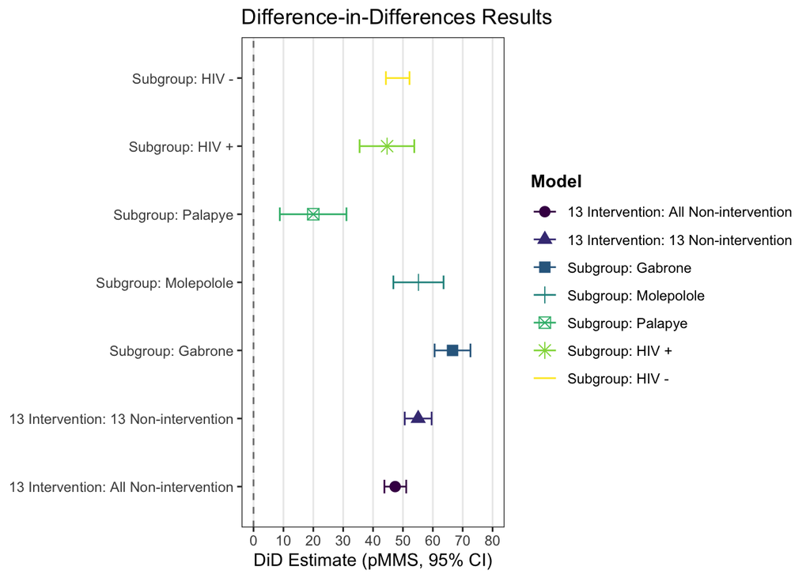

```r
forest_plot_new <- ggplot(
  data = did_data_new,
  aes(
    x = Estimate,
    y = Model,
    color = Model,
    shape = Model
  )
) +
  scale_color_viridis_d() +
  # A: 95% CI
  geom_errorbarh(aes(xmin = Lower_CI, xmax = Upper_CI), height = 0.2) +

  # B: point estimate
  geom_point(size = 3) +
  geom_vline(xintercept = 0, linetype = "dashed", color = "gray50") +

  # C: Set X range and label
  scale_x_continuous(
    name = "DiD Estimate (pMMS, 95% CI)",
    limits = c(0, 80),
    breaks = seq(0, 80, by = 10)
  ) +

  # D: tidy pattern
  theme_bw() +
  theme(
    panel.grid.major.y = element_blank(),
    panel.grid.minor = element_blank(),
    legend.position = "right",
    legend.title = element_text(face = "bold")
  ) +

  # E: Y axis label
  labs(y = NULL, title = "Difference-in-Differences Results")
print(forest_plot_new)
```

## 4.3 Effectiveness Outcomes

### 4.3.1 Mean change in difference between first and second hemoglobin

During the intervention period, there were 421 pregnant women in the intervention clinics and 747 in the non-intervention clinics who had one hemoglobin measurement before 24 weeks of gestation and a second hemoglobin measurement on or after 24 weeks of gestation. During the pre-intervention period, there were 1,944 pregnant women in the intervention clinics and 3,727 pregnant women in the non-intervention clinics, who had one hemoglobin measurement before 24 weeks of gestation and a second hemoglobin measurement on or after 24 weeks of gestation. The results indicate that the change in hemoglobin was reduced by 0.048 g/dL more in the intervention clinics relative to the non-intervention clinics post-intervention.

```r
# Filter for those with both hemoglobins and compute change
filtered_table <- combined_table %>%
  mutate(
    lmp_calc = delivdate - nga * 7,
    gage_firsthb  = as.numeric((hb_date  - lmp_calc) / 7),
    gage_secondhb = as.numeric((hb2_date - lmp_calc) / 7)
  ) %>%
  filter(gage_firsthb < 24, gage_secondhb >= 24) %>%
  filter(!is.na(firsthb), !is.na(secondhb))

hb_table <- filtered_table %>%
  mutate(hb_change = secondhb - firsthb)

# Run DID model
hb_did_model <- lm(hb_change ~ treated + post + treated:post, data = hb_table)
summary(hb_did_model)
```

```
Call:
lm(formula = hb_change ~ treated + post + treated:post, data = hb_table)

Residuals:
    Min      1Q  Median      3Q     Max
-9.2061 -0.8796 -0.0486  0.7939  7.3204

Coefficients:
             Estimate Std. Error t value Pr(>|t|)
(Intercept)  -0.29386    0.02359 -12.459   <2e-16 ***
treated      -0.05753    0.04029  -1.428    0.153
post          0.17846    0.05772   3.092    0.002 **
treated:post -0.04750    0.09656  -0.492    0.623
---
Signif. codes:  0 '***' 0.001 '**' 0.01 '*' 0.05 '.' 0.1 ' ' 1

Residual standard error: 1.44 on 6835 degrees of freedom
Multiple R-squared:  0.002259,  Adjusted R-squared:  0.001822
F-statistic:  5.16 on 3 and 6835 DF,  p-value: 0.001461
```

```r
confint(hb_did_model)
```

```
                   2.5 %      97.5 %
(Intercept)  -0.34009303 -0.24761827
treated      -0.13650556  0.02143908
post          0.06530388  0.29161759
treated:post -0.23678600  0.14178720
```

```r
# Get group means
hb_table %>%
  group_by(treated, post) %>%
  summarise(
    n = n(),
    mean_hb_change = mean(hb_change, na.rm = TRUE),
    sd_hb_change = sd(hb_change, na.rm = TRUE)
  )
```

```
# A tibble: 4 × 5
# Groups:   treated [2]
  treated  post     n mean_hb_change sd_hb_change
    <dbl> <dbl> <int>          <dbl>        <dbl>
1       0     0  3727         -0.294         1.43
2       0     1   747         -0.115         1.51
3       1     0  1944         -0.351         1.44
4       1     1   421         -0.220         1.39
```

Results were consistent when restricting the non-intervention clinics to the 13 clinics originally eligible and in the subgroup analyses by region and HIV status.

```r
## Subgroup Analysis
hb_table_sub <- hb_table %>%
  mutate(region = case_when(
    cliniccode %in% c(5302, 5303, 5306, 5318, 5323) ~ "Molepolole",     #compare tp all other noninterventions
    cliniccode %in% c(15312, 15325, 15329, 15331, 15335, 15341) ~ "Gaborone",
    cliniccode %in% c(3201, 3319) ~ "Palapye",
    TRUE ~ "Other"
  ))
##Gaborone
gabs_did_hb <- hb_table %>%
  filter(cliniccode %in% c(intervention_Gab_subset, nonintervention_Gab_subset)) %>%
  mutate(treated = ifelse(cliniccode %in% intervention_Gab_subset, 1, 0))

gabs_model_hb <- lm(hb_change ~ treated + post + treated:post, data = gabs_did_hb)
summary(gabs_model_hb)
```

```
Call:
lm(formula = hb_change ~ treated + post + treated:post, data = gabs_did_hb)

Residuals:
    Min      1Q  Median      3Q     Max
-8.6829 -0.8829 -0.0829  0.8171  7.3517

Coefficients:
             Estimate Std. Error t value Pr(>|t|)
(Intercept)  -0.25823    0.05303  -4.869  1.2e-06 ***
treated      -0.05890    0.07094  -0.830    0.406
post          0.19093    0.11620   1.643    0.100
treated:post -0.12550    0.15567  -0.806    0.420
---
Signif. codes:  0 '***' 0.001 '**' 0.01 '*' 0.05 '.' 0.1 ' ' 1

Residual standard error: 1.502 on 2290 degrees of freedom
Multiple R-squared:  0.002142,  Adjusted R-squared:  0.0008351
F-statistic: 1.639 on 3 and 2290 DF,  p-value: 0.1783
```

```r
#CI
confint(gabs_model_hb)
```

```
                   2.5 %      97.5 %
(Intercept)  -0.36222373 -0.15423512
treated      -0.19800697  0.08021386
post         -0.03693176  0.41879345
treated:post -0.43077070  0.17976474
```

```r
#get 4 variables listed
gabs_did_hb %>%
  group_by(treated, post) %>%
  summarise(
    n = n(),
    mean_hb_change = mean(hb_change, na.rm = TRUE),
    sd_hb_change = sd(hb_change, na.rm = TRUE)
  )
```

```
# A tibble: 4 × 5
# Groups:   treated [2]
  treated  post     n mean_hb_change sd_hb_change
    <dbl> <dbl> <int>          <dbl>        <dbl>
1       0     0   802        -0.258          1.47
2       0     1   211        -0.0673         1.63
3       1     0  1016        -0.317          1.51
4       1     1   265        -0.252          1.45
```

```r
##Molepolole
mole_did_hb <- hb_table %>%
  filter(cliniccode %in% c(intervention_Mol_subset, nonintervention_Mol_subset)) %>%
  mutate(treated = ifelse(cliniccode %in% intervention_Mol_subset, 1, 0))

mole_model_hb <- lm(hb_change ~ treated + post + treated:post, data = mole_did_hb)
summary(mole_model_hb)
```

```
Call:
lm(formula = hb_change ~ treated + post + treated:post, data = mole_did_hb)

Residuals:
    Min      1Q  Median      3Q     Max
-5.0770 -0.7872  0.0230  0.7230  7.0128

Coefficients:
             Estimate Std. Error t value Pr(>|t|)
(Intercept)  -0.31278    0.07118  -4.394 1.22e-05 ***
treated      -0.11027    0.09196  -1.199    0.231
post          0.19429    0.14280   1.361    0.174
treated:post  0.08524    0.20167   0.423    0.673
---
Signif. codes:  0 '***' 0.001 '**' 0.01 '*' 0.05 '.' 0.1 ' ' 1

Residual standard error: 1.35 on 1121 degrees of freedom
Multiple R-squared:  0.006725,  Adjusted R-squared:  0.004067
F-statistic:  2.53 on 3 and 1121 DF,  p-value: 0.05585
```

```r
#CI
confint(mole_model_hb)
```

```
                  2.5 %     97.5 %
(Intercept)  -0.4524329 -0.1731227
treated      -0.2906985  0.0701574
post         -0.0858986  0.4744794
treated:post -0.3104478  0.4809267
```

```r
#get 4 variables listed
mole_did_hb %>%
  group_by(treated, post) %>%
  summarise(
    n = n(),
    mean_hb_change = mean(hb_change, na.rm = TRUE),
    sd_hb_change = sd(hb_change, na.rm = TRUE)
  )
```

```
# A tibble: 4 × 5
# Groups:   treated [2]
  treated  post     n mean_hb_change sd_hb_change
    <dbl> <dbl> <int>          <dbl>        <dbl>
1       0     0   360         -0.313         1.23
2       0     1   119         -0.118         1.55
3       1     0   538         -0.423         1.39
4       1     1   108         -0.144         1.30
```

```r
##Palapye
pal_did_hb <- hb_table %>%
  filter(cliniccode %in% c(intervention_Pal_subset, nonintervention_Pal_subset)) %>%
  mutate(treated = ifelse(cliniccode %in% intervention_Pal_subset, 1, 0))

pal_model_hb <- lm(hb_change ~ treated + post + treated:post, data = pal_did_hb)
summary(pal_model_hb)
```

```
Call:
lm(formula = hb_change ~ treated + post + treated:post, data = pal_did_hb)

Residuals:
    Min      1Q  Median      3Q     Max
-4.6582 -0.7786 -0.0786  0.7418  5.5214

Coefficients:
             Estimate Std. Error t value Pr(>|t|)
(Intercept)  -0.32141    0.06399  -5.023 6.08e-07 ***
treated      -0.02038    0.09329  -0.218    0.827
post          0.17454    0.17938   0.973    0.331
treated:post -0.05358    0.27245  -0.197    0.844
---
Signif. codes:  0 '***' 0.001 '**' 0.01 '*' 0.05 '.' 0.1 ' ' 1

Residual standard error: 1.341 on 937 degrees of freedom
Multiple R-squared:  0.001499,  Adjusted R-squared:  -0.001698
F-statistic: 0.4689 on 3 and 937 DF,  p-value: 0.704
```

```r
#CI
confint(pal_model_hb)
```

```
                  2.5 %     97.5 %
(Intercept)  -0.4469833 -0.1958413
treated      -0.2034599  0.1626947
post         -0.1774958  0.5265704
treated:post -0.5882615  0.4811100
```

```r
#get 4 variables listed
pal_did_hb %>%
  group_by(treated, post) %>%
  summarise(
    n = n(),
    mean_hb_change = mean(hb_change, na.rm = TRUE),
    sd_hb_change = sd(hb_change, na.rm = TRUE)
  )
```

```
# A tibble: 4 × 5
# Groups:   treated [2]
  treated  post     n mean_hb_change sd_hb_change
    <dbl> <dbl> <int>          <dbl>        <dbl>
1       0     0   439         -0.321         1.35
2       0     1    64         -0.147         1.49
3       1     0   390         -0.342         1.31
4       1     1    48         -0.221         1.32
```

```r
##HIV status
# HIV-positive subset
hb_hivpos <- hb_table %>% filter(hivpos == 1)     #use dataset from total analysis
# HIV-negative subset
hb_hivneg <- hb_table %>% filter(hivpos == 0)
# DID
# For HIV-positive
did_hivpos_hb <- lm(hb_change ~ treated + post + treated:post, data = hb_hivpos)
summary(did_hivpos_hb)
```

```
Call:
lm(formula = hb_change ~ treated + post + treated:post, data = hb_hivpos)

Residuals:
    Min      1Q  Median      3Q     Max
-9.0674 -0.9244 -0.0674  0.8326  7.3326

Coefficients:
              Estimate Std. Error t value Pr(>|t|)
(Intercept)  -0.432562   0.061670  -7.014 3.91e-12 ***
treated      -0.043006   0.103944  -0.414   0.6791
post          0.406898   0.160038   2.543   0.0111 *
treated:post -0.004544   0.276805  -0.016   0.9869
---
Signif. codes:  0 '***' 0.001 '**' 0.01 '*' 0.05 '.' 0.1 ' ' 1

Residual standard error: 1.57 on 1165 degrees of freedom
Multiple R-squared:  0.008417,  Adjusted R-squared:  0.005863
F-statistic: 3.296 on 3 and 1165 DF,  p-value: 0.01988
```

```r
confint(did_hivpos_hb) #CI
```

```
                  2.5 %     97.5 %
(Intercept)  -0.5535575 -0.3115660
treated      -0.2469447  0.1609318
post          0.0929027  0.7208933
treated:post -0.5476364  0.5385482
```

```r
hb_table %>% # 4 proportions, need to change the dataset to be consistent
  filter(hivpos == 1) %>%
  group_by(treated, post) %>%
  summarise(
    n = n(),
    mean_hb_change = mean(hb_change, na.rm = TRUE),
    sd_hb_change = sd(hb_change, na.rm = TRUE)
  )
```

```
# A tibble: 4 × 5
# Groups:   treated [2]
  treated  post     n mean_hb_change sd_hb_change
    <dbl> <dbl> <int>          <dbl>        <dbl>
1       0     0   648        -0.433          1.58
2       0     1   113        -0.0257         1.57
3       1     0   352        -0.476          1.54
4       1     1    56        -0.0732         1.65
```

```r
# For HIV-negative
did_hivneg_hb <- lm(hb_change ~ treated + post + treated:post, data = hb_hivneg)
summary(did_hivneg_hb)
```

```
Call:
lm(formula = hb_change ~ treated + post + treated:post, data = hb_hivneg)

Residuals:
    Min      1Q  Median      3Q     Max
-8.6765 -0.8353 -0.0353  0.7647  7.3430

Coefficients:
             Estimate Std. Error t value Pr(>|t|)
(Intercept)  -0.26466    0.02543 -10.409   <2e-16 ***
treated      -0.05886    0.04357  -1.351   0.1768
post          0.13328    0.06153   2.166   0.0304 *
treated:post -0.05277    0.10243  -0.515   0.6065
---
Signif. codes:  0 '***' 0.001 '**' 0.01 '*' 0.05 '.' 0.1 ' ' 1

Residual standard error: 1.411 on 5664 degrees of freedom
Multiple R-squared:  0.0015,    Adjusted R-squared:  0.0009715
F-statistic: 2.837 on 3 and 5664 DF,  p-value: 0.03665
```

```r
confint(did_hivneg_hb)
```

```
                   2.5 %      97.5 %
(Intercept)  -0.31450791 -0.21481980
treated      -0.14427171  0.02655538
post          0.01265254  0.25389914
treated:post -0.25356275  0.14802770
```

```r
hb_table %>% # 4 proportions
  filter(hivpos == 0) %>%
  group_by(treated, post) %>%
  summarise(
    n = n(),
    mean_hb_change = mean(hb_change, na.rm = TRUE),
    sd_hb_change = sd(hb_change, na.rm = TRUE)
  )
```

```
# A tibble: 4 × 5
# Groups:   treated [2]
  treated  post     n mean_hb_change sd_hb_change
    <dbl> <dbl> <int>          <dbl>        <dbl>
1       0     0  3079         -0.265         1.40
2       0     1   634         -0.131         1.51
3       1     0  1590         -0.324         1.42
4       1     1   365         -0.243         1.35
```

```r
## Sensitivity Analysis
hb_change_sensitivity <- hb_table %>%
  filter(cliniccode %in% c(intervention_clinics_did, nonintervention_clinics_did))
sensitivity_hb_change <- lm(hb_change ~ treated + post + treated:post, data = hb_change_sensitivity)
summary(sensitivity_hb_change)
```

```
Call:
lm(formula = hb_change ~ treated + post + treated:post, data = hb_change_sensitivity)

Residuals:
    Min      1Q  Median      3Q     Max
-8.6486 -0.8486 -0.0486  0.7878  7.3204

Coefficients:
             Estimate Std. Error t value Pr(>|t|)
(Intercept)  -0.28782    0.03572  -8.057    1e-15 ***
treated      -0.06357    0.04824  -1.318   0.1877
post          0.19213    0.08039   2.390   0.0169 *
treated:post -0.06117    0.11120  -0.550   0.5823
---
Signif. codes:  0 '***' 0.001 '**' 0.01 '*' 0.05 '.' 0.1 ' ' 1

Residual standard error: 1.429 on 4356 degrees of freedom
Multiple R-squared:  0.002714,  Adjusted R-squared:  0.002028
F-statistic: 3.952 on 3 and 4356 DF,  p-value: 0.007946
```

```r
confint(sensitivity_hb_change) #CI
```

```
                   2.5 %      97.5 %
(Intercept)  -0.35785789 -0.21778233
treated      -0.15814726  0.03100971
post          0.03453501  0.34973465
treated:post -0.27919090  0.15684391
```

```r
hb_change_sensitivity %>%
  group_by(treated, post) %>%
  summarise(
    n = n(),
    mean_hb_change = mean(hb_change, na.rm = TRUE),
    sd_hb_change = sd(hb_change, na.rm = TRUE)
  )
```

```
# A tibble: 4 × 5
# Groups:   treated [2]
  treated  post     n mean_hb_change sd_hb_change
    <dbl> <dbl> <int>          <dbl>        <dbl>
1       0     0  1601        -0.288          1.39
2       0     1   394        -0.0957         1.58
3       1     0  1944        -0.351          1.44
4       1     1   421        -0.220          1.39
```

```r
# Create dataset
did_data_new_2 <- tibble(
  # Column representing the Y-axis outcomes/models
  Model = c(
    "13 Intervention: All Non-intervention",
    "13 Intervention: 13 Non-intervention",
    "Subgroup: Gabrone",
    "Subgroup: Molepolole",
    "Subgroup: Palapye",
    "Subgroup: HIV +",
    "Subgroup: HIV -"
  ),
  # DiD Estimate (change in hemoglobin column)
  Estimate = c(-0.048, -0.061, -0.126, 0.085, -0.054, -0.005, -0.053),
  # Lower CI (2.5 %)
  Lower_CI = c(-0.237, -0.279, -0.431, -0.310, -0.588, -0.548, -0.254),
  # Upper CI (97.5 %)
  Upper_CI = c(0.142, 0.157, 0.180, 0.481, 0.481, 0.539, 0.148)
) %>%
  mutate(
    # Check if the confidence interval crosses zero (Sig if both bounds are > 0 or < 0)
    Significance = if_else(
      condition = (Lower_CI * Upper_CI) > 0,
      true = "Sig",
      false = "n.s."
    ),
    # Ensure the outcomes are plotted in the correct order (reversing the list order for presentation)
    Model = fct_inorder(Model)
  )

print(did_data_new_2)
```

```
# A tibble: 7 × 5
  Model                                 Estimate Lower_CI Upper_CI Significance
  <fct>                                    <dbl>    <dbl>    <dbl> <chr>
1 13 Intervention: All Non-intervention   -0.048   -0.237    0.142 n.s.
2 13 Intervention: 13 Non-intervention    -0.061   -0.279    0.157 n.s.
3 Subgroup: Gabrone                       -0.126   -0.431    0.18  n.s.
4 Subgroup: Molepolole                     0.085   -0.31     0.481 n.s.
5 Subgroup: Palapye                       -0.054   -0.588    0.481 n.s.
6 Subgroup: HIV +                         -0.005   -0.548    0.539 n.s.
7 Subgroup: HIV -                         -0.053   -0.254    0.148 n.s.
```

```
`height` was translated to `width`.
```

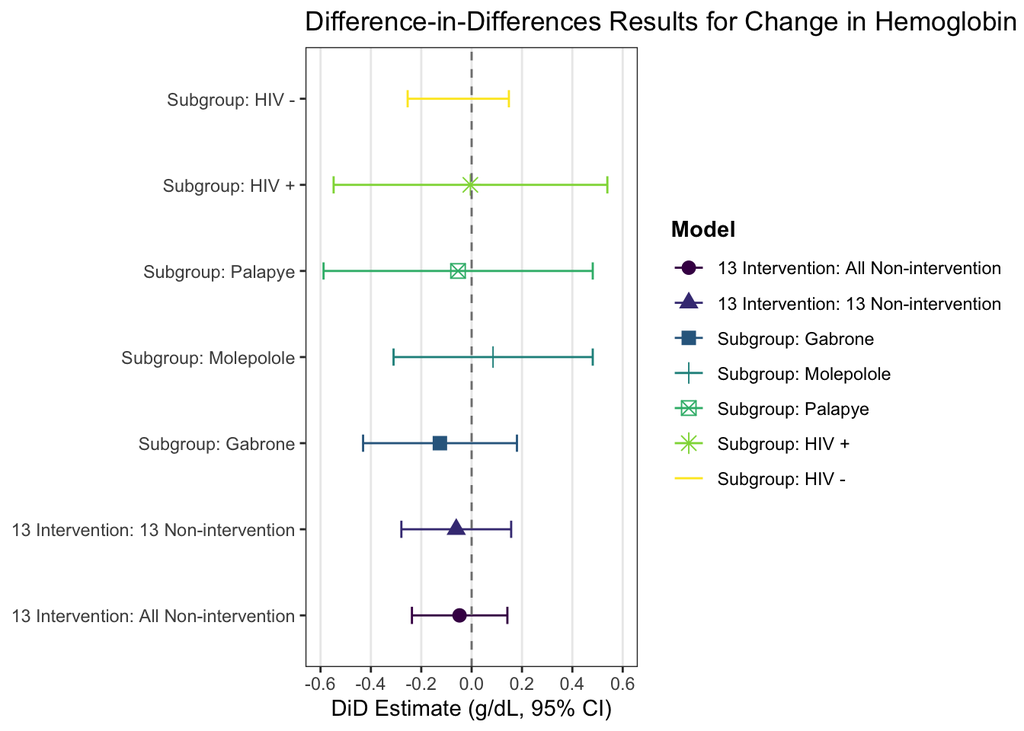

```r
forest_plot_new_2 <- ggplot(
  data = did_data_new_2,
  aes(
    x = Estimate,
    y = Model,
    color = Model,
    shape = Model
  )
) +
  scale_color_viridis_d() +
  # A: 95% CI
  geom_errorbarh(aes(xmin = Lower_CI, xmax = Upper_CI), height = 0.2) +

  # B: point estimate
  geom_point(size = 3) +
  geom_vline(xintercept = 0, linetype = "dashed", color = "gray50") +

  # C: Set X range and label
  scale_x_continuous(
    name = "DiD Estimate (g/dL, 95% CI)",
    limits = c(-0.6, 0.6),
    breaks = seq(-0.6, 0.6, by = 0.2),
    labels = function(x) sprintf("%.1f", x)
  ) +

  # D: tidy pattern
  theme_bw() +
  theme(
    panel.grid.major.y = element_blank(),
    panel.grid.minor = element_blank(),
    legend.position = "right",
    legend.title = element_text(face = "bold")
  ) +

  # E: Y axis label
  labs(y = NULL, title = "Difference-in-Differences Results for Change in Hemoglobin")

print(forest_plot_new_2)
```

### 4.3.2 Mean change in second hemoglobin (H2)

During the intervention period, there were 710 pregnant women in intervention clinics and 1,213 in non-intervention clinics who had a hemoglobin measured on or after 24 weeks gestation, During the pre-intervention period, there were 3,178 pregnant women and 6,437 pregnant women who had a hemoglobin measured on or after 24 weeks gestation. The overall DiD estimate was 0.016 g/dL (95% CI: –0.129 to 0.160), with similar findings in the sensitivity and subgroup analyses.

```r
# Filter for those with a second hb value
secondhb_table <- combined_table %>%
  filter(!is.na(secondhb))
# Run DID model
secondhb_did_model <- lm(secondhb ~ treated + post + treated:post, data = secondhb_table)
summary(secondhb_did_model)
```

```
Call:
lm(formula = secondhb ~ treated + post + treated:post, data = secondhb_table)

Residuals:
    Min      1Q  Median      3Q     Max
-6.3726 -0.8726  0.1274  0.9274  7.4666

Coefficients:
             Estimate Std. Error t value Pr(>|t|)
(Intercept)  11.27258    0.01767 637.855  < 2e-16 ***
treated       0.06081    0.03074   1.978   0.0479 *
post          0.21266    0.04438   4.792 1.67e-06 ***
treated:post  0.01578    0.07371   0.214   0.8305
---
Signif. codes:  0 '***' 0.001 '**' 0.01 '*' 0.05 '.' 0.1 ' ' 1

Residual standard error: 1.418 on 11534 degrees of freedom
Multiple R-squared:  0.003808,  Adjusted R-squared:  0.003549
F-statistic:  14.7 on 3 and 11534 DF,  p-value: 1.5e-09
```

```r
# Group summaries
secondhb_table %>%
  group_by(treated, post) %>%
  summarise(
    n = n(),
    mean_secondhb = mean(secondhb, na.rm = TRUE),
    sd_secondhb = sd(secondhb, na.rm = TRUE)
  )
```

```
# A tibble: 4 × 5
# Groups:   treated [2]
  treated  post     n mean_secondhb sd_secondhb
    <dbl> <dbl> <int>         <dbl>       <dbl>
1       0     0  6437          11.3        1.42
2       0     1  1213          11.5        1.44
3       1     0  3178          11.3        1.43
4       1     1   710          11.6        1.32
```

```r
#CI
confint(secondhb_did_model)
```

```
                     2.5 %     97.5 %
(Intercept)  11.2379390378 11.3072218
treated       0.0005504519  0.1210603
post          0.1256676202  0.2996580
treated:post -0.1287113519  0.1602762
```

```r
## Subgroup Analysis
hb2_table_sub <- secondhb_table %>%
  mutate(region = case_when(
    cliniccode %in% c(5302, 5303, 5306, 5318, 5323) ~ "Molepolole",     #compare tp all other noninterventions
    cliniccode %in% c(15312, 15325, 15329, 15331, 15335, 15341) ~ "Gaborone",
    cliniccode %in% c(3201, 3319) ~ "Palapye",
    TRUE ~ "Other"
  ))
##Gaborone
gabs_did_hb2 <- secondhb_table %>%
  filter(cliniccode %in% c(intervention_Gab_subset, nonintervention_Gab_subset)) %>%
  mutate(treated = ifelse(cliniccode %in% intervention_Gab_subset, 1, 0))

gabs_model_hb2 <- lm(secondhb ~ treated + post + treated:post, data = gabs_did_hb2)
summary(gabs_model_hb2)
```

```
Call:
lm(formula = secondhb ~ treated + post + treated:post, data = gabs_did_hb2)

Residuals:
    Min      1Q  Median      3Q     Max
-5.7438 -0.8257  0.1039  0.9438  7.5039

Coefficients:
             Estimate Std. Error t value Pr(>|t|)
(Intercept)  11.35621    0.03720 305.293  < 2e-16 ***
treated      -0.06015    0.05013  -1.200    0.230
post          0.38758    0.08457   4.583 4.72e-06 ***
treated:post -0.07603    0.11137  -0.683    0.495
---
Signif. codes:  0 '***' 0.001 '**' 0.01 '*' 0.05 '.' 0.1 ' ' 1

Residual standard error: 1.396 on 3943 degrees of freedom
Multiple R-squared:  0.01049,   Adjusted R-squared:  0.009739
F-statistic: 13.94 on 3 and 3943 DF,  p-value: 4.89e-09
```

```r
#CI
confint(gabs_model_hb2)
```

```
                  2.5 %      97.5 %
(Intercept)  11.2832815 11.42913869
treated      -0.1584218  0.03812672
post          0.2217763  0.55337748
treated:post -0.2943685  0.14231161
```

```r
#get 4 variables listed
gabs_did_hb2 %>%
  group_by(treated, post) %>%
  summarise(
    n = n(),
    mean_hb = mean(secondhb, na.rm = TRUE),
    sd_hb = sd(secondhb, na.rm = TRUE)
  )
```

```
# A tibble: 4 × 5
# Groups:   treated [2]
  treated  post     n mean_hb sd_hb
    <dbl> <dbl> <int>   <dbl> <dbl>
1       0     0  1409    11.4  1.35
2       0     1   338    11.7  1.39
3       1     0  1727    11.3  1.45
4       1     1   473    11.6  1.32
```

```r
##Molepolole
mole_did_hb2 <- secondhb_table %>%
  filter(cliniccode %in% c(intervention_Mol_subset, nonintervention_Mol_subset)) %>%
  mutate(treated = ifelse(cliniccode %in% intervention_Mol_subset, 1, 0))

mole_model_hb2 <- lm(secondhb ~ treated + post + treated:post, data = mole_did_hb2)
summary(mole_model_hb2)
```

```
Call:
lm(formula = secondhb ~ treated + post + treated:post, data = mole_did_hb2)

Residuals:
    Min      1Q  Median      3Q     Max
-5.6362 -0.8362  0.1546  0.9638  5.5899

Coefficients:
             Estimate Std. Error t value Pr(>|t|)
(Intercept)  11.51014    0.05909 194.788   <2e-16 ***
treated       0.02604    0.07775   0.335    0.738
post          0.09927    0.12428   0.799    0.425
treated:post -0.09005    0.17227  -0.523    0.601
---
Signif. codes:  0 '***' 0.001 '**' 0.01 '*' 0.05 '.' 0.1 ' ' 1

Residual standard error: 1.426 on 1718 degrees of freedom
Multiple R-squared:  0.0003781, Adjusted R-squared:  -0.001367
F-statistic: 0.2166 on 3 and 1718 DF,  p-value: 0.8849
```

```r
#CI
confint(mole_model_hb2)
```

```
                  2.5 %     97.5 %
(Intercept)  11.3942404 11.6260345
treated      -0.1264463  0.1785332
post         -0.1444826  0.3430312
treated:post -0.4279384  0.2478325
```

```r
#get 4 variables listed
mole_did_hb2 %>%
  group_by(treated, post) %>%
  summarise(
    n = n(),
    mean = mean(secondhb, na.rm = TRUE),
    sd = sd(secondhb, na.rm = TRUE)
  )
```

```
# A tibble: 4 × 5
# Groups:   treated [2]
  treated  post     n  mean    sd
    <dbl> <dbl> <int> <dbl> <dbl>
1       0     0   582  11.5  1.47
2       0     1   170  11.6  1.34
3       1     0   796  11.5  1.43
4       1     1   174  11.5  1.29
```

```r
##Palapye
pal_did_hb2 <- secondhb_table %>%
  filter(cliniccode %in% c(intervention_Pal_subset, nonintervention_Pal_subset)) %>%
  mutate(treated = ifelse(cliniccode %in% intervention_Pal_subset, 1, 0))

pal_model_hb2 <- lm(secondhb ~ treated + post + treated:post, data = pal_did_hb2)
summary(pal_model_hb2)
```

```
Call:
lm(formula = secondhb ~ treated + post + treated:post, data = pal_did_hb2)

Residuals:
    Min      1Q  Median      3Q     Max
-4.9810 -0.7810  0.1190  0.9147  4.3147

Coefficients:
              Estimate Std. Error t value Pr(>|t|)
(Intercept)  11.181039   0.051206 218.354   <2e-16 ***
treated       0.004304   0.073975   0.058   0.9536
post         -0.257383   0.150653  -1.708   0.0878 .
treated:post  0.335532   0.234904   1.428   0.1534
---
Signif. codes:  0 '***' 0.001 '**' 0.01 '*' 0.05 '.' 0.1 ' ' 1

Residual standard error: 1.366 on 1519 degrees of freedom
Multiple R-squared:  0.002264,  Adjusted R-squared:  0.0002935
F-statistic: 1.149 on 3 and 1519 DF,  p-value: 0.3281
```

```r
#CI
confint(pal_model_hb)
```

```
                  2.5 %     97.5 %
(Intercept)  -0.4469833 -0.1958413
treated      -0.2034599  0.1626947
post         -0.1774958  0.5265704
treated:post -0.5882615  0.4811100
```

```r
#get 4 variables listed
pal_did_hb2 %>%
  group_by(treated, post) %>%
  summarise(
    n = n(),
    mean_hb = mean(secondhb, na.rm = TRUE),
    sd_hb = sd(secondhb, na.rm = TRUE)
  )
```

```
# A tibble: 4 × 5
# Groups:   treated [2]
  treated  post     n mean_hb sd_hb
    <dbl> <dbl> <int>   <dbl> <dbl>
1       0     0   712    11.2  1.37
2       0     1    93    10.9  1.49
3       1     0   655    11.2  1.35
4       1     1    63    11.3  1.33
```

```r
##HIV status
# HIV-positive subset
hb2_hivpos <- secondhb_table %>% filter(hivpos == 1)     #use dataset from total analysis
# HIV-negative subset
hb2_hivneg <- secondhb_table %>% filter(hivpos == 0)
# DID
# For HIV-positive
did_hivpos_hb2 <- lm(secondhb ~ treated + post + treated:post, data = hb2_hivpos)
summary(did_hivpos_hb2)
```

```
Call:
lm(formula = secondhb ~ treated + post + treated:post, data = hb2_hivpos)

Residuals:
    Min      1Q  Median      3Q     Max
-5.8188 -1.0044  0.0812  1.0956  7.4812

Coefficients:
             Estimate Std. Error t value Pr(>|t|)
(Intercept)  10.71880    0.04772 224.618   <2e-16 ***
treated      -0.01441    0.08210  -0.176   0.8606
post          0.23594    0.12516   1.885   0.0596 .
treated:post  0.08138    0.21006   0.387   0.6985
---
Signif. codes:  0 '***' 0.001 '**' 0.01 '*' 0.05 '.' 0.1 ' ' 1

Residual standard error: 1.595 on 1979 degrees of freedom
Multiple R-squared:  0.003571,  Adjusted R-squared:  0.00206
F-statistic: 2.364 on 3 and 1979 DF,  p-value: 0.06937
```

```r
confint(did_hivpos_hb2) #CI
```

```
                    2.5 %     97.5 %
(Intercept)  10.625213360 10.8123874
treated      -0.175418010  0.1465892
post         -0.009521132  0.4813941
treated:post -0.330580784  0.4933321
```